# MSACSR_Project_R

Buse Uzun

2025-07-22

# SAMPLE ABSTRACT

Society is growing and improving rapidly, improvement comes with change. Change of people, and their demands. Demand and price certainly go hand in hand, the same rule applies to the supply of new houses. As demand rises, new houses will be built and sold increasingly.

In this report, the investigation will be the change of monthly supply of new houses in the United States. Supply means ratio of new houses on sale to new houses sold.

# ANALYSIS

```r
msacsr_data <- read.csv("MSACSR.csv")
head(msacsr_data)
```

|  | DATE | MSACSR |
| --- | --- | --- |
| 1 | 1963-01-01 | 4.7 |
| 2 | 1963-02-01 | 6.6 |
| 3 | 1963-03-01 | 6.4 |
| 4 | 1963-04-01 | 5.3 |
| 5 | 1963-05-01 | 5.1 |
| 6 | 1963-06-01 | 6.0 |

```r
class(msacsr_data)
```

```
## [1] "data.frame"
```

As MSACSR is in the dataframe format, we need to make it a time series object by applying the following step:

```r
msacsr_ts <- ts(msacsr_data[,2], start=c(1963,1), frequency = 12)
class(msacsr_ts)
```

```
## [1] "ts"
```

Now, “ts” format is obtained.

```r
str(msacsr_ts)
```

```
##  Time-Series [1:742] from 1963 to 2025: 4.7 6.6 6.4 5.3 5.1 6 4.6 5.6 5.4 5.9 ...
```

```r
summary(msacsr_ts)
```

```
##    Min. 1st Qu.  Median    Mean 3rd Qu.    Max.
##   3.300   4.900   5.900   6.133   7.000  12.200
```

Minimum supply of new houses in a month is 3.3. First quartile value gives the 25th percentile of the data, monthly supply of new houses for the 25% of the data is 4.9 or less. Similarly, 50% of the data is equal to or below 5.9. 75% of the data is equal to or below 7, and lastly the maximum supply of new houses in a month is 12.2. Averagely, the monthly supply of new houses is 6.133.

```r
sum(is.na(msacsr_ts))
```

```
## [1] 0
```

There are no NA values in the data.

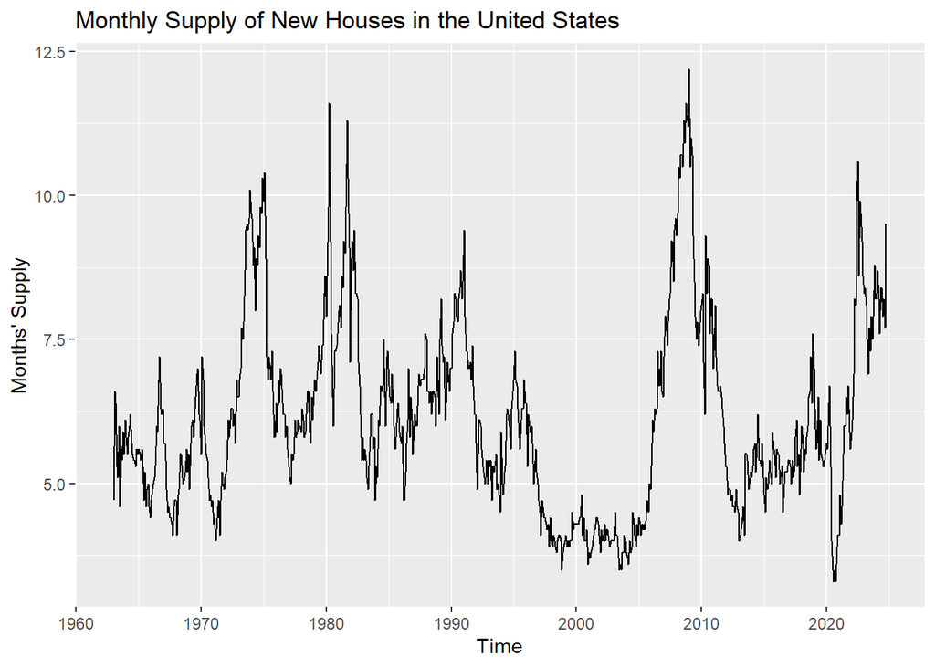

```r
autoplot(msacsr_ts, main = "Monthly Supply of New Houses in the United States", ylab = "Months' Supply")
```

When the time series plot of MSACSR data is observed, there can be seasonality. Mean is varying lightly, and variance is unstable. Series do not seem to be stable, further analysis is needed to come to a conclusion.

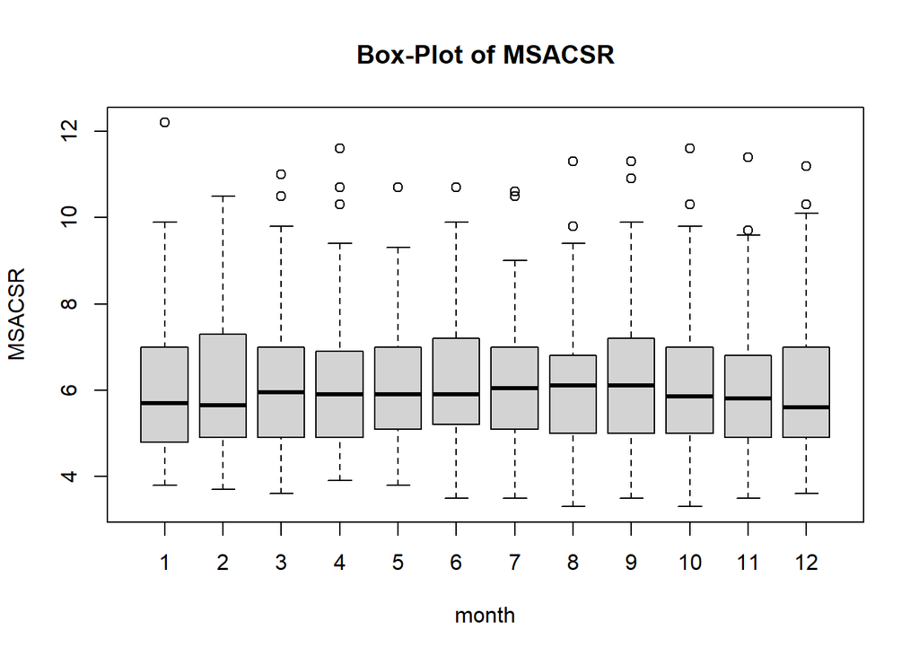

```r
boxplot(msacsr_ts~cycle(msacsr_ts), xlab="month", ylab="MSACSR", main ="Box-Plot of MSACSR")
```

When box-plot of MSACSR for each month is checked, means look steady but there can be seasonality due to small variation.

STL can be used to split the series into components to make a more detailed observation.

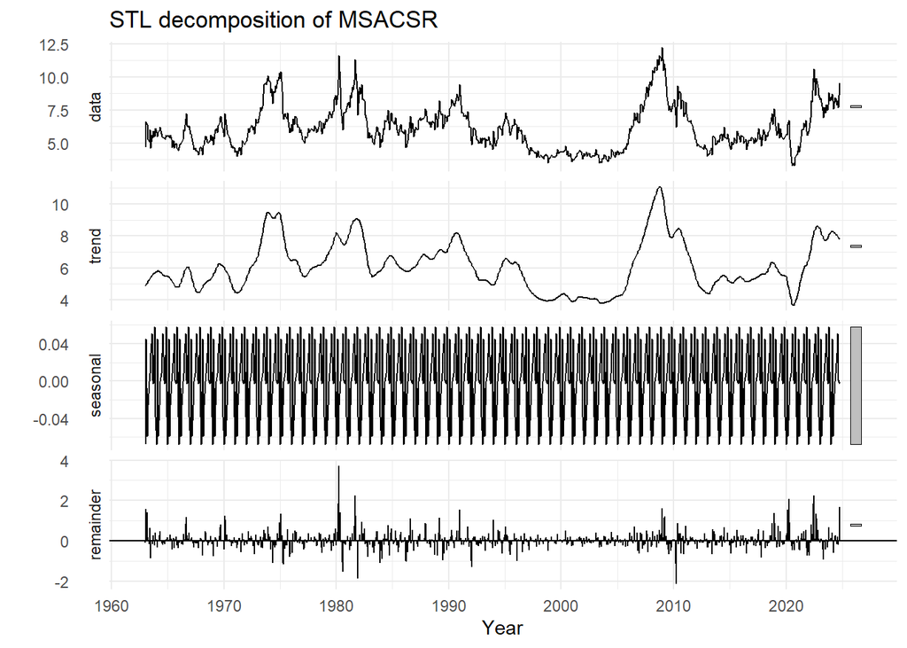

```r
msacsr_ts %>%
  stl(t.window=13, s.window="periodic", robust=TRUE) %>%
  autoplot()+ xlab("Year") +
  ggtitle("STL decomposition of MSACSR")+theme_minimal()
```

Giving odd values to window function enables us to see the whole year and more. When third graph is analyzed, there is a repetitive behavior. Hence, there seems to be seasonality. From the remainder plot, some peaks can be observed which indicates outliers.

Before cleaning the data, it should be split into train and test parts for cross-validation in future analysis.

```r
#Train data
msacsr_tr <- window(msacsr_ts, end=c(time(msacsr_ts)[length(msacsr_ts) - 12]))
#Test data
msacsr_test <- window(msacsr_ts, start = c(time(msacsr_ts)[length(msacsr_ts) - 12 + 1]))
msacsr_test
```

```
##      Jan Feb Mar Apr May Jun Jul Aug Sep Oct Nov Dec
## 2023                                         8.8 8.2
## 2024 8.3 8.7 8.2 7.6 8.4 8.4 7.9 8.2 7.7 9.5
```

Now, analysis can be proceeded with anomaly detection to clean the data and investigate the outliers further. First, data should be converted to tibble.

```r
msacsr_anomaly <- msacsr_data
msacsr_anomaly$month <- paste(msacsr_anomaly$DATE, "01", sep="-")
msacsr_anomaly$month <- as.Date(msacsr_anomaly$month,format="%Y-%m-%d")
msacsr_anomaly <- msacsr_anomaly %>% select(month,MSACSR)
msacsr_tibble <- as_tibble(msacsr_anomaly)
class(msacsr_tibble)
```

```
## [1] "tbl_df"     "tbl"        "data.frame"
```

```r
head(msacsr_tibble)
```

| month | MSACSR |
| --- | --- |
| 1963-01-01 | 4.7 |
| 1963-02-01 | 6.6 |
| 1963-03-01 | 6.4 |
| 1963-04-01 | 5.3 |
| 1963-05-01 | 5.1 |
| 1963-06-01 | 6.0 |

Now, anomaly detection can be applied.

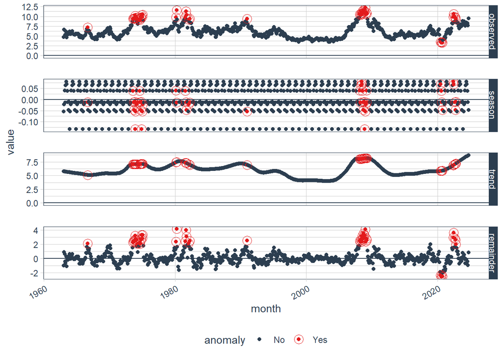

```r
msacsr_tibble %>%
  anomalize::time_decompose(MSACSR, method = "stl", frequency ="auto", trend = "auto") %>%
  anomalize::anomalize(remainder, method = "gesd", alpha = 0.05, max_anoms = 0.2) %>%
  anomalize::plot_anomaly_decomposition()
```

Instead of decomposing, following code could also be used.

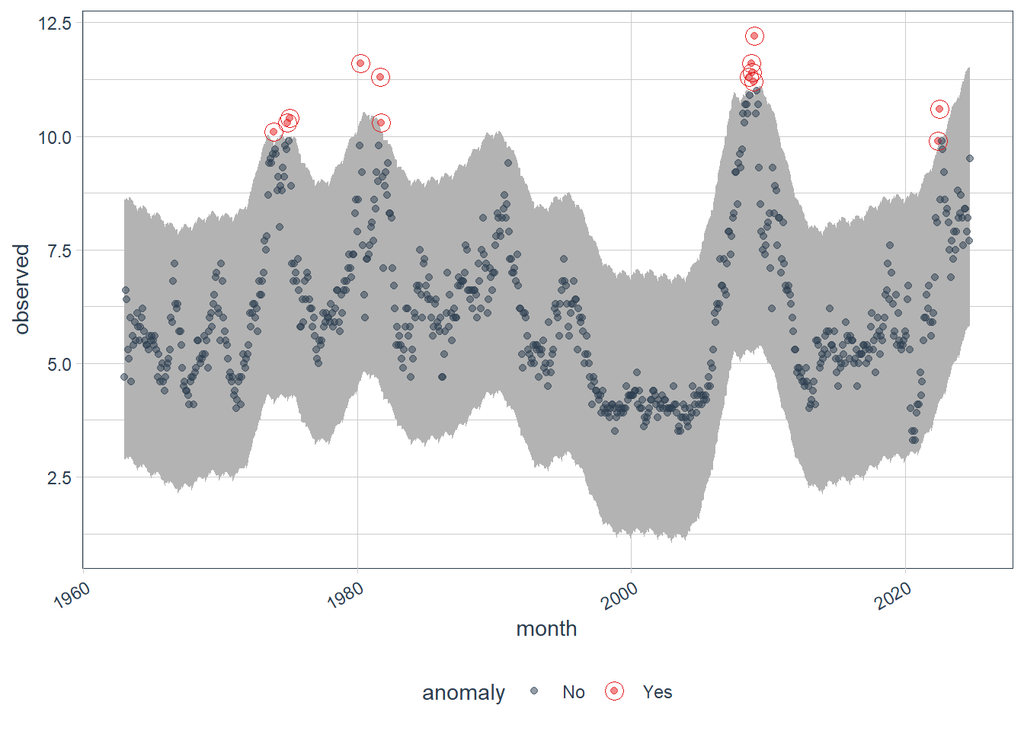

```r
msacsr_tibble %>%
  anomalize::time_decompose(MSACSR) %>%
  anomalize::anomalize(remainder) %>%
  anomalize::time_recompose() %>%
  anomalize::plot_anomalies(time_recomposed = TRUE, ncol = 3, alpha_dots = 0.5)
```

Above plots indicate that there are anomalies/outliers in the data. Anomalies should be extracted from the data.

```r
msacsr_tibble %>%
  anomalize::time_decompose(MSACSR) %>%
  anomalize::anomalize(remainder) %>%
  anomalize::time_recompose() %>%
  filter(anomaly == 'Yes')
```

| month | observed | season | trend | remainder | remainder_l1 | remainder_l2 | anomaly | recomposed_l1 | recomposed_l2 |
| --- | --- | --- | --- | --- | --- | --- | --- | --- | --- |
| 1973-12-01 | 10.1 | -0.13354555 | 7.052445 | 3.181101 | -2.827774 | 2.880349 | Yes | 4.091125 | 9.799248 |
| 1974-12-01 | 10.3 | -0.13354555 | 7.126588 | 3.306957 | -2.827774 | 2.880349 | Yes | 4.165268 | 9.873391 |
| 1975-02-01 | 10.4 | -0.02132244 | 7.116149 | 3.305174 | -2.827774 | 2.880349 | Yes | 4.267052 | 9.975175 |
| 1980-04-01 | 11.6 | -0.01320464 | 7.460720 | 4.152484 | -2.827774 | 2.880349 | Yes | 4.619741 | 10.327864 |
| 1981-09-01 | 11.3 | -0.01259779 | 7.311319 | 4.001279 | -2.827774 | 2.880349 | Yes | 4.470947 | 10.179070 |
| 1981-10-01 | 10.3 | -0.04656419 | 7.260340 | 3.086224 | -2.827774 | 2.880349 | Yes | 4.386001 | 10.094124 |
| 2008-08-01 | 11.3 | 0.03862864 | 8.077529 | 3.183842 | -2.827774 | 2.880349 | Yes | 5.288383 | 10.996506 |
| 2008-10-01 | 11.6 | -0.04656419 | 8.111880 | 3.534684 | -2.827774 | 2.880349 | Yes | 5.237542 | 10.945665 |
| 2008-11-01 | 11.4 | -0.01057769 | 8.129056 | 3.281522 | -2.827774 | 2.880349 | Yes | 5.290704 | 10.998827 |
| 2008-12-01 | 11.2 | -0.13354555 | 8.146232 | 3.187314 | -2.827774 | 2.880349 | Yes | 5.184912 | 10.893035 |

[output cut: 3 more lines]

Alpha and max anoms can be changed as following:

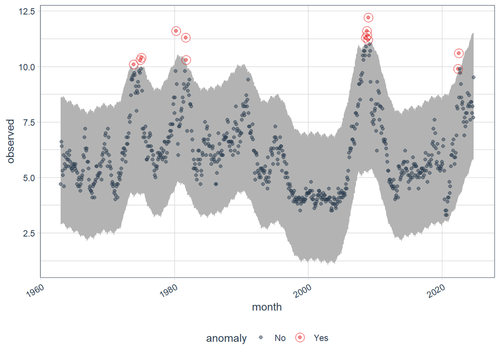

```r
msacsr_tibble %>%
  anomalize::time_decompose(MSACSR) %>%
  anomalize::anomalize(remainder,alpha=0.05) %>%
  anomalize::time_recompose() %>%
  anomalize::plot_anomalies(time_recomposed = TRUE, ncol = 3, alpha_dots = 0.5)
```

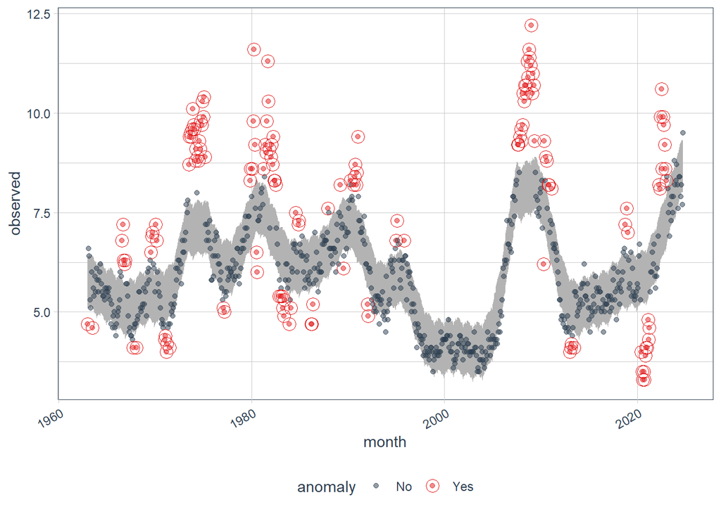

```r
msacsr_tibble %>%
  anomalize::time_decompose(MSACSR) %>%
  anomalize::anomalize(remainder,alpha=0.5) %>%
  anomalize::time_recompose() %>%
  anomalize::plot_anomalies(time_recomposed = TRUE, ncol = 3, alpha_dots = 0.5)
```

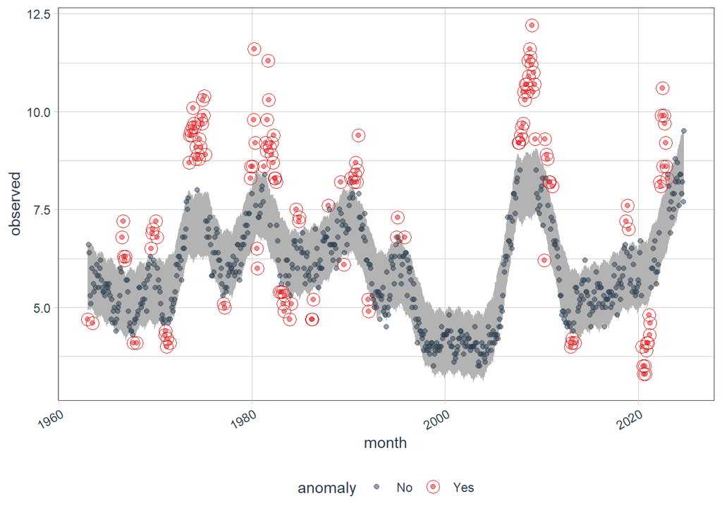

```r
msacsr_tibble %>%
  anomalize::time_decompose(MSACSR) %>%
  anomalize::anomalize(remainder,alpha=0.3,max_anoms = 0.2) %>%
  anomalize::time_recompose() %>%
  anomalize::plot_anomalies(time_recomposed = TRUE, ncol = 3, alpha_dots = 0.5)
```

There are many outliers due to alpha value being 0.3.

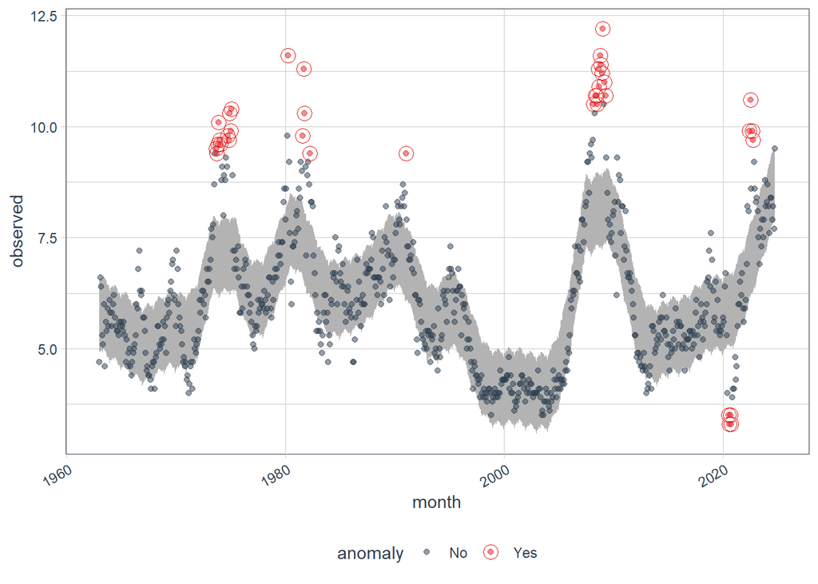

```r
msacsr_tibble %>%
  anomalize::time_decompose(MSACSR) %>%
  anomalize::anomalize(remainder,alpha=0.3,max_anoms = 0.05) %>%
  anomalize::time_recompose() %>%
  anomalize::plot_anomalies(time_recomposed = TRUE, ncol = 3, alpha_dots = 0.5)
```

MSACSR data can be cleaned using tsclean function.

```r
msacsr_train <- tsclean(msacsr_tr)
class(msacsr_train)
```

```
## [1] "ts"
```

Cleaned data can be plotted to investigate changes.

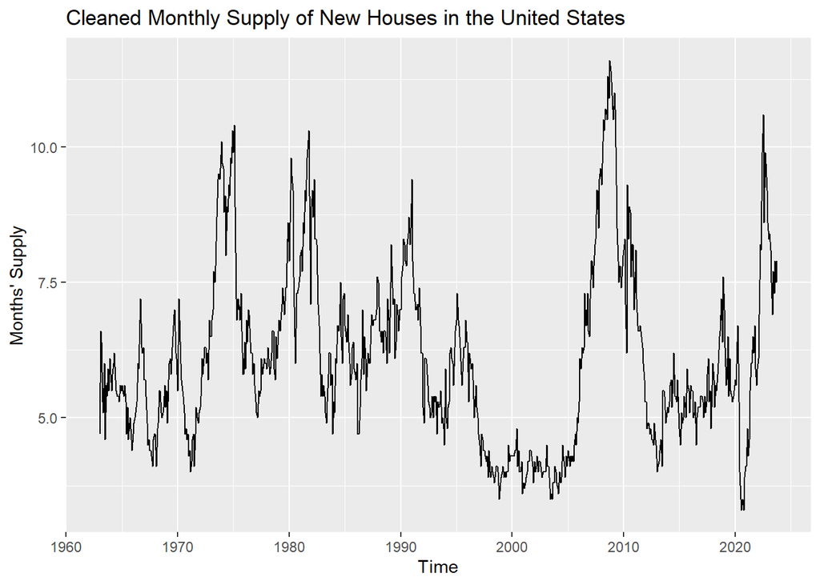

```r
autoplot(msacsr_train, main = "Cleaned Monthly Supply of New Houses in the United States",ylab = "Months' Supply")
```

BoxCox plot should be checked to see if there is any need for transformation.

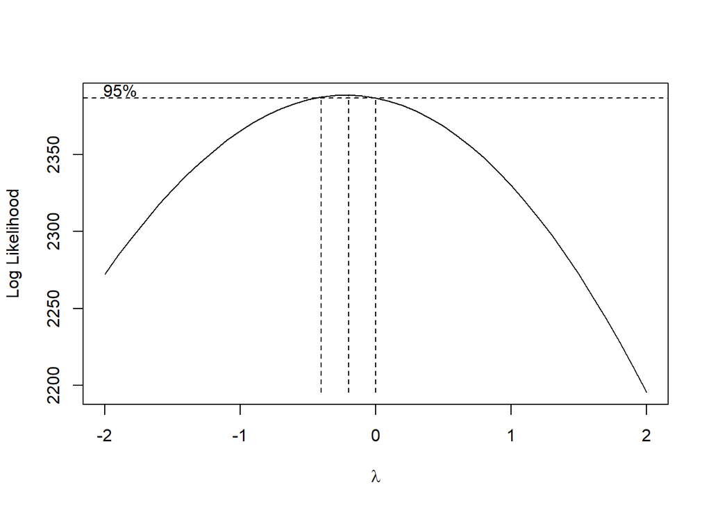

```r
BoxCox.ar(msacsr_train,method = c("yule-walker"))
```

Since y axis has values with big difference, a transformation should be applied. Lambda function of BoxCox helps finding the suitable lambda.

```r
lambda <- BoxCox.lambda(msacsr_train)
lambda
```

```
## [1] -0.4239587
```

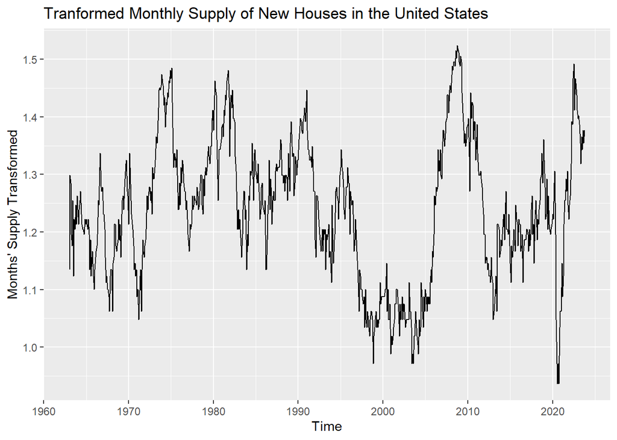

```r
msacsr_t <- BoxCox(msacsr_train,lambda)
#check stationarity of transformed series
autoplot(msacsr_t, main = "Tranformed Monthly Supply of New Houses in the United States",ylab = "Months' Supply Transformed")
```

Data is cleaned and tranformed. Hence, ACF and PACF plots can be interpreted.

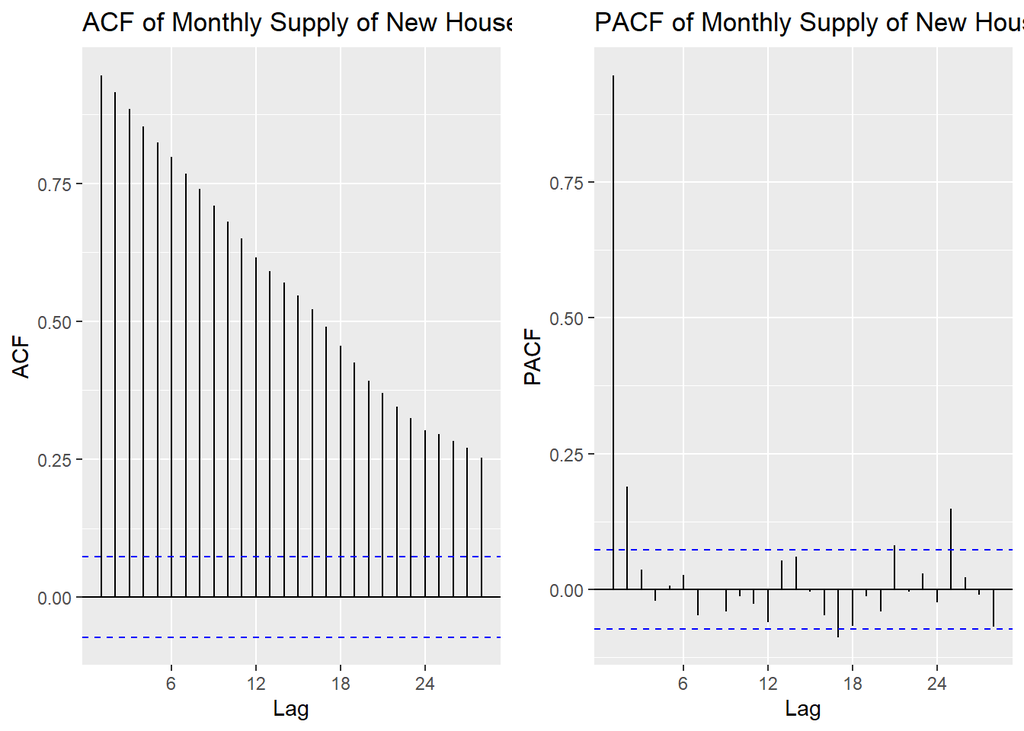

```r
p1 <- ggAcf(msacsr_t, main="ACF of Monthly Supply of New Houses in the US")
p2 <- ggPacf(msacsr_t, main="PACF of Monthly Supply of New Houses in the US")
grid.arrange(p1,p2,nrow=1)
```

Since ACF plot has slow linear decay there is a non-stationarity problem. For inspecting stationarity and seasonality following tests can be applied.

```r
kpss.test(msacsr_t, null=c("Level"))
```

```
##
##  KPSS Test for Level Stationarity
##
## data:  msacsr_t
## KPSS Level = 0.5405, Truncation lag parameter = 6, p-value = 0.03254
```

Since p-value is 0.032 which is smaller than 0.05, we reject H0. Thus, the series is not stationary according to KPSS test.

```r
kpss.test(msacsr_t, null=c("Trend"))
```

```
##
##  KPSS Test for Trend Stationarity
##
## data:  msacsr_t
## KPSS Trend = 0.36407, Truncation lag parameter = 6, p-value = 0.01
```

KPSS test for trend has a p-value of 0.01, we reject H0. Therefore, series has stochastic trend. Differencing can be applied to solve this issue.

```r
#Find mean to choose between c or nc
mean(msacsr_train)
```

```
## [1] 6.0903
```

Since mean is not zero, use the ADF test with c

```r
adfTest(msacsr_t, lags=2, type="c")
```

```
##
## Title:
##  Augmented Dickey-Fuller Test
##
## Test Results:
##   PARAMETER:
##     Lag Order: 2
##   STATISTIC:
##     Dickey-Fuller: -3.3294
##   P VALUE:
##     0.01535
##
## Description:
##  Tue Jul 22 17:16:38 2025 by user: buseu
```

P-value is smaller than 0.05, reject H0. We do not have any unit roots, series is stationary according to ADF.

Use hegy test to check if there is unit root problem.

```r
test_hegy <- hegy.test(msacsr_t, deterministic = c(1,0,0), lag.method = "AIC")
summary(test_hegy)
```

```
##
##  HEGY test for unit roots
##
## data:  msacsr_t
##
## Fitted model
## ------------
##
## Call:
## lm(formula = dx ~ 0 + ypi + xreg)
##
## Residuals:
##       Min        1Q    Median        3Q       Max
## -0.170615 -0.024295  0.000522  0.022824  0.164017
##
## Coefficients:
##           Estimate Std. Error t value Pr(>|t|)
## ypiYpi1  -0.003788   0.001052  -3.602 0.000338 ***
## ypiYpi2  -0.148067   0.017397  -8.511  < 2e-16 ***
## ypiYpi3  -0.049906   0.009437  -5.288 1.65e-07 ***
## ypiYpi4  -0.087639   0.008191 -10.700  < 2e-16 ***
## ypiYpi5  -0.119786   0.015972  -7.500 1.93e-13 ***
## ypiYpi6  -0.132192   0.015090  -8.760  < 2e-16 ***
## ypiYpi7  -0.205427   0.020744  -9.903  < 2e-16 ***
## ypiYpi8  -0.129910   0.020620  -6.300 5.23e-10 ***
## ypiYpi9  -0.247829   0.021605 -11.471  < 2e-16 ***
## ypiYpi10  0.068239   0.022387   3.048 0.002389 **
## ypiYpi11 -0.281885   0.023168 -12.167  < 2e-16 ***
## ypiYpi12  0.069376   0.025087   2.765 0.005834 **
## xreg      0.056490   0.015690   3.600 0.000340 ***
## ---
## Signif. codes:  0 '***' 0.001 '**' 0.01 '*' 0.05 '.' 0.1 ' ' 1
##
## Residual standard error: 0.03721 on 705 degrees of freedom
## Multiple R-squared:  0.8769, Adjusted R-squared:  0.8746
## F-statistic: 386.4 on 13 and 705 DF,  p-value: < 2.2e-16
##
## Test statistic
## --------------
##         statistic p-value
## t_1        -3.602  0.0055 **
## t_2        -8.511       0 ***
## F_3:4     76.1926       0 ***
## F_5:6     73.0443       0 ***
## F_7:8     74.6007       0 ***
## F_9:10    72.4008       0 ***
## F_11:12   79.6388       0 ***
## F_2:12   455.9488       0 ***
## F_1:12   418.2667       0 ***
## ---
## Signif. codes: 0 '***' 0.001 '**' 0.01 '*' 0.05 '.' 0.1 ' ' 1
##
## Deterministic terms: constant
## Lag selection criterion and order: AIC, 0
## P-values: based on response surface regressions
```

According to hegy test there is no regular nor seasonal unit roots.

To determine if we have a stochastic or a deterministic trend we may apply Canova-Hansen Test.

H0: The series is deterministic and stationary.

H1: The series have stochastic seasonality.

```r
ch.test(msacsr_t,type = "dummy",sid=c(1:12))
```

```
##
##  Canova and Hansen test for seasonal stability
##
## data:  msacsr_t
##
##      statistic pvalue
## [1,]    0.8887  0.705
## ---
## Signif. codes: 0 '***' 0.001 '**' 0.01 '*' 0.05 '.' 0.1 ' ' 1
##
## Test type: seasonal dummies
## NW covariance matrix lag order: 20
## First order lag: no
## Other regressors: no
## P-values: interpolation in original tables
```

Since p-value is greater than 0.05, we fail to reject H0. The series has deterministic and stationary seasonality.

Difference can be taken since series has stochastic trend according to KPSS test. HEGY test shows no unit roots but these tests might be misleading.

```r
ndiffs(msacsr_t)
```

```
## [1] 1
```

According to ndiffs, 1 regular difference can be taken.

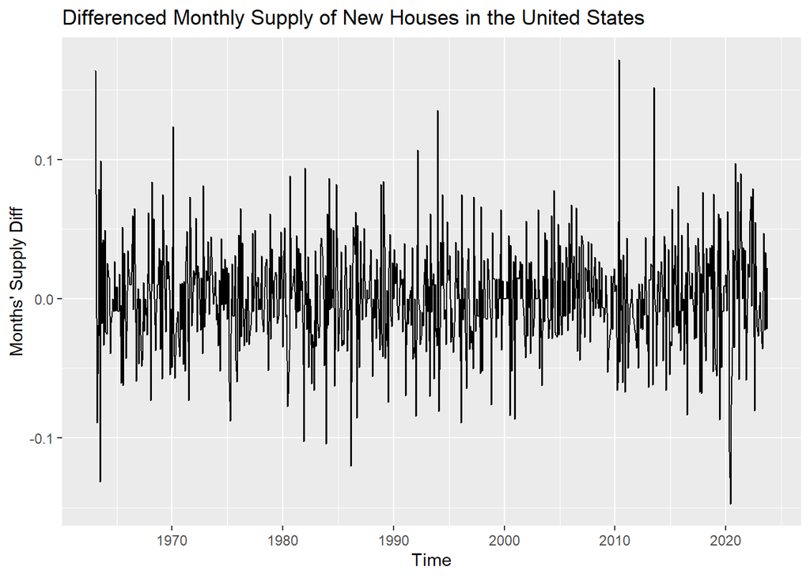

```r
dif_msacsr <- diff(msacsr_t)
autoplot(dif_msacsr, main = "Differenced Monthly Supply of New Houses in the United States",ylab = "Months' Supply Diff")
```

After one regular differencing the time series plot looks stationary. KPSS test can be checked again.

```r
kpss.test(dif_msacsr, null=c("Trend"))
```

```
##
##  KPSS Test for Trend Stationarity
##
## data:  dif_msacsr
## KPSS Trend = 0.030214, Truncation lag parameter = 6, p-value = 0.1
```

After differencing p-value is 0.1 so we fail to reject H0. Non-stationarity problem is solved.

```r
adfTest(dif_msacsr, lags=2, type="nc")
```

```
##
## Title:
##  Augmented Dickey-Fuller Test
##
## Test Results:
##   PARAMETER:
##     Lag Order: 2
##   STATISTIC:
##     Dickey-Fuller: -16.8883
##   P VALUE:
##     0.01
##
## Description:
##  Tue Jul 22 17:16:39 2025 by user: buseu
```

P-value is smaller than 0.05, reject H0. We do not have any unit roots, series is stationary according to ADF.

```r
test_hegy <- HEGY.test(dif_msacsr, itsd=c(0,0,0),regvar=0, selectlags=list(mode="aic", Pmax=12))
test_hegy$stats
```

```
##               Stat. p-value
## tpi_1     -8.531197    0.01
## tpi_2     -8.280845    0.01
## Fpi_3:4   64.535600    0.01
## Fpi_5:6   64.148904    0.01
## Fpi_7:8   83.434219    0.01
## Fpi_9:10  52.785019    0.01
## Fpi_11:12 75.117656    0.01
## Fpi_2:12  51.147484      NA
## Fpi_1:12  49.834387      NA
```

According to HEGY test there is no regular nor seasonal unit roots.

```r
ch.test(dif_msacsr,type = "dummy",sid=c(1:12))
```

```
##
##  Canova and Hansen test for seasonal stability
##
## data:  dif_msacsr
##
##      statistic pvalue
## [1,]    0.9519  0.684
## ---
## Signif. codes: 0 '***' 0.001 '**' 0.01 '*' 0.05 '.' 0.1 ' ' 1
##
## Test type: seasonal dummies
## NW covariance matrix lag order: 20
## First order lag: no
## Other regressors: no
## P-values: interpolation in original tables
```

Since p-value is greater than 0.05, we fail to reject H0. The series has deterministic and stationary seasonality.

ACF and PACF plots can be examined as series is stationary now.

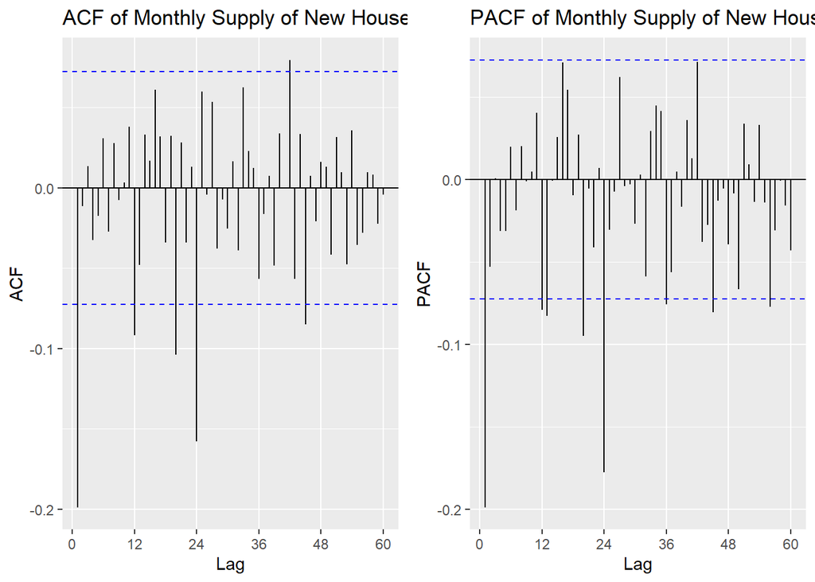

```r
p1 <- ggAcf(dif_msacsr, lag.max=60, main="ACF of Monthly Supply of New Houses in the US")
p2 <- ggPacf(dif_msacsr, lag.max=60, main="PACF of Monthly Supply of New Houses in the US")
grid.arrange(p1,p2,nrow=1)
```

According to ACF plot, there is a significant spike at lag 1, but it can also be taken as exponential decay. ACF has seasonal spikes at 12th and 24th lags. On PACF plot there is a significant spike at lag 1, and seasonal spikes at lags 12 and 24 again.

*Suggested models:*

$SARIMA(1,1,0)(2,0,2)_{12}$

$SARIMA(0,1,1)(2,0,2)_{12}$

$SARIMA(1,1,0)(1,0,2)_{12}$

$SARIMA(0,1,1)(1,0,2)_{12}$

$SARIMA(1,1,0)(2,0,1)_{12}$

$SARIMA(0,1,1)(1,0,1)_{12}$

$SARIMA(1,1,0)(2,0,0)_{12}$

$SARIMA(0,1,1)(0,0,2)_{12}$

$SARIMA(0,1,1)(2,0,1)_{12}$

Now, we can check the significance of these models by the following code.

$SARIMA(1,1,0)(2,0,2)_{12}$

```r
fit_sarima1 = Arima(msacsr_t, order=c(1,1,0), seasonal=list(order=c(2,0,2), period=12))
fit_sarima1
```

```
## Series: msacsr_t
## ARIMA(1,1,0)(2,0,2)[12]
##
## Coefficients:
##           ar1    sar1     sar2     sma1     sma2
##       -0.2180  0.4065  -0.0722  -0.5598  -0.0519
## s.e.   0.0368  0.3191   0.2122   0.3184   0.2591
##
## sigma^2 = 0.001387:  log likelihood = 1365.92
## AIC=-2719.84   AICc=-2719.72   BIC=-2692.29
```

Now, check the significance of parameters by dividing each value to its s.e.

$SARIMA(0,1,1)(2,0,2)_{12}$

```r
fit_sarima2 = Arima(msacsr_t, order=c(0,1,1), seasonal=list(order=c(2,0,2), period=12))
fit_sarima2
```

```
## Series: msacsr_t
## ARIMA(0,1,1)(2,0,2)[12]
##
## Coefficients:
##           ma1    sar1     sar2     sma1     sma2
##       -0.2323  0.3891  -0.0553  -0.5420  -0.0737
## s.e.   0.0368  0.3211   0.2161   0.3198   0.2627
##
## sigma^2 = 0.001382:  log likelihood = 1367.16
## AIC=-2722.32   AICc=-2722.2   BIC=-2694.77
```

SAR(2) and SMA(2) are not significant.

$SARIMA(1,1,0)(1,0,2)_{12}$

```r
fit_sarima3 = Arima(msacsr_t, order=c(1,1,0), seasonal=list(order=c(1,0,2), period=12))
fit_sarima3
```

```
## Series: msacsr_t
## ARIMA(1,1,0)(1,0,2)[12]
##
## Coefficients:
##           ar1    sar1     sma1     sma2
##       -0.2182  0.3174  -0.4717  -0.1361
## s.e.   0.0368  0.1583   0.1576   0.0553
##
## sigma^2 = 0.001385:  log likelihood = 1365.86
## AIC=-2721.72   AICc=-2721.64   BIC=-2698.76
```

Since all the parameters are significant, model 3 is significant.

$SARIMA(0,1,1)(1,0,2)_{12}$

```r
fit_sarima4 = Arima(msacsr_t, order=c(0,1,1), seasonal=list(order=c(1,0,2), period=12))
fit_sarima4
```

```
## Series: msacsr_t
## ARIMA(0,1,1)(1,0,2)[12]
##
## Coefficients:
##           ma1    sar1     sma1     sma2
##       -0.2326  0.3225  -0.4761  -0.1377
## s.e.   0.0367  0.1564   0.1559   0.0554
##
## sigma^2 = 0.00138:  log likelihood = 1367.12
## AIC=-2724.24   AICc=-2724.15   BIC=-2701.28
```

Since all the parameters are significant, model 4 is significant.

$SARIMA(1,1,0)(2,0,1)_{12}$

```r
fit_sarima5 = Arima(msacsr_t, order=c(1,1,0), seasonal=list(order=c(2,0,1), period=12))
fit_sarima5
```

```
## Series: msacsr_t
## ARIMA(1,1,0)(2,0,1)[12]
##
## Coefficients:
##           ar1    sar1     sar2     sma1
##       -0.2181  0.4675  -0.1127  -0.6211
## s.e.   0.0368  0.1198   0.0492   0.1180
##
## sigma^2 = 0.001385:  log likelihood = 1365.9
## AIC=-2721.81   AICc=-2721.72   BIC=-2698.85
```

Since all the parameters are significant, model 5 is significant.

$SARIMA(0,1,1)(1,0,1)_{12}$

```r
fit_sarima6 = Arima(msacsr_t, order=c(0,1,1), seasonal=list(order=c(1,0,1), period=12))
fit_sarima6
```

```
## Series: msacsr_t
## ARIMA(0,1,1)(1,0,1)[12]
##
## Coefficients:
##           ma1    sar1     sma1
##       -0.2342  0.5822  -0.7743
## s.e.   0.0366  0.0777   0.0601
##
## sigma^2 = 0.001388:  log likelihood = 1364.63
## AIC=-2721.27   AICc=-2721.21   BIC=-2702.9
```

Since all the parameters are significant, model 6 is significant.

$SARIMA(1,1,0)(2,0,0)_{12}$

```r
fit_sarima7 = Arima(msacsr_t, order=c(1,1,0), seasonal=list(order=c(2,0,0), period=12))
fit_sarima7
```

```
## Series: msacsr_t
## ARIMA(1,1,0)(2,0,0)[12]
##
## Coefficients:
##           ar1     sar1     sar2
##       -0.2078  -0.1243  -0.1797
## s.e.   0.0367   0.0376   0.0377
##
## sigma^2 = 0.001407:  log likelihood = 1360.05
## AIC=-2712.1   AICc=-2712.05   BIC=-2693.74
```

Since all the parameters are significant, model 7 is significant.

$SARIMA(0,1,1)(0,0,2)_{12}$

```r
fit_sarima8 = Arima(msacsr_t, order=c(0,1,1), seasonal=list(order=c(0,0,2), period=12))
fit_sarima8
```

```
## Series: msacsr_t
## ARIMA(0,1,1)(0,0,2)[12]
##
## Coefficients:
##           ma1     sma1     sma2
##       -0.2278  -0.1664  -0.1990
## s.e.   0.0367   0.0372   0.0376
##
## sigma^2 = 0.001385:  log likelihood = 1365.36
## AIC=-2722.72   AICc=-2722.66   BIC=-2704.35
```

Since all the parameters are significant, model 8 is significant.

$SARIMA(0,1,1)(2,0,1)_{12}$

```r
fit_sarima9 = Arima(msacsr_t, order=c(0,1,1), seasonal=list(order=c(2,0,1), period=12))
fit_sarima9
```

```
## Series: msacsr_t
## ARIMA(0,1,1)(2,0,1)[12]
##
## Coefficients:
##           ma1    sar1     sar2     sma1
##       -0.2322  0.4763  -0.1126  -0.6295
## s.e.   0.0367  0.1178   0.0490   0.1158
##
## sigma^2 = 0.00138:  log likelihood = 1367.13
## AIC=-2724.26   AICc=-2724.18   BIC=-2701.3
```

Since all the parameters are significant, model 9 is significant.

Model 9 has the minimum AIC value. We can proceed with $SARIMA(0,1,1)(2,0,1)_{12}$

Here is the auto.arima results for good measure:

```r
auto.arima(msacsr_t)
```

```
## Series: msacsr_t
## ARIMA(0,1,1)(1,0,2)[12]
##
## Coefficients:
##           ma1    sar1     sma1     sma2
##       -0.2326  0.3225  -0.4761  -0.1377
## s.e.   0.0367  0.1564   0.1559   0.0554
##
## sigma^2 = 0.00138:  log likelihood = 1367.12
## AIC=-2724.24   AICc=-2724.15   BIC=-2701.28
```

All parameters are significant.

**Diagnostic Checks:** Now we can proceed with diagnostic checking.

We need to obtain the residuals.

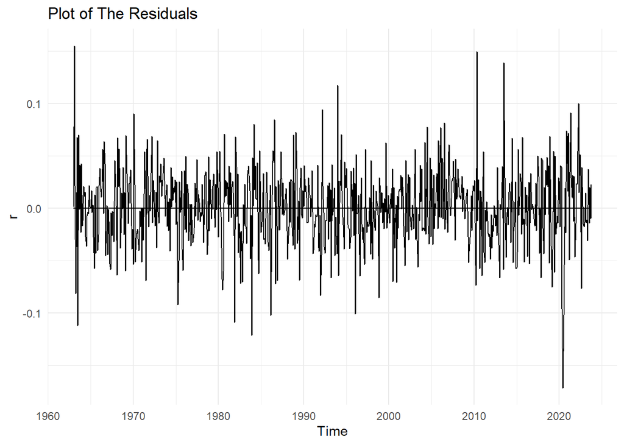

```r
r=resid(fit_sarima9)
autoplot(r)+geom_line(y=0)+theme_minimal()+ggtitle("Plot of The Residuals")
```

As the residuals are scattered around zero, they have zero mean.

*QQ-PLOT*

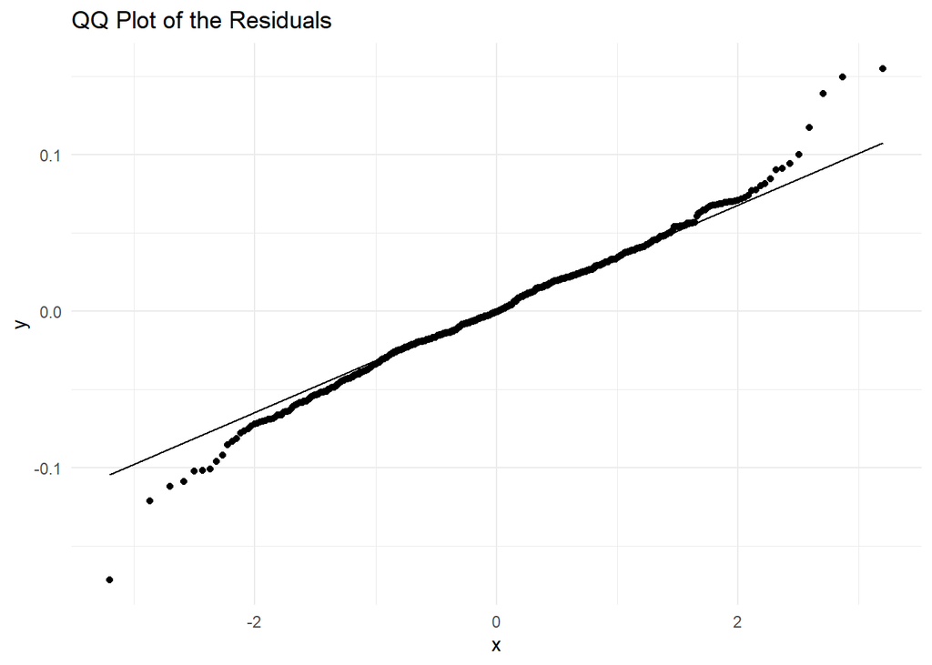

```r
ggplot(r, aes(sample = r)) +stat_qq()+geom_qq_line()+ggtitle("QQ Plot of the Residuals")+theme_minimal()
```

When QQ Plot is interpreted, it can be seen that the residuals have a heavy tailed distribution due to the slight S shape. Also, there can be some outliers.

*HISTOGRAM*

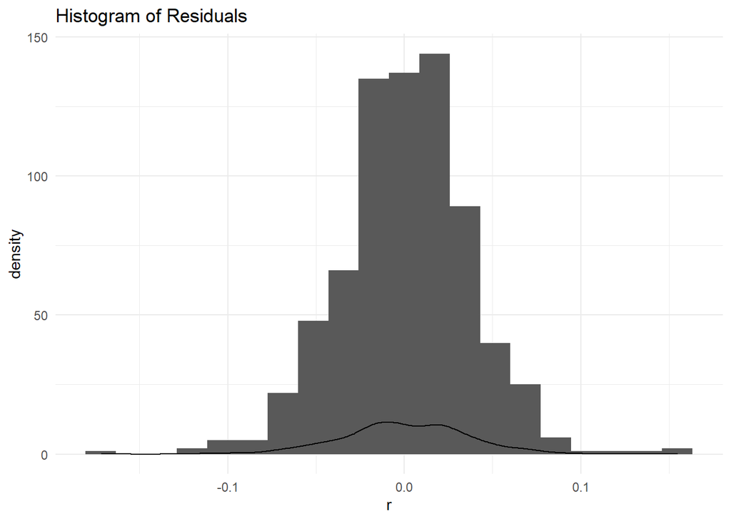

```r
ggplot(r,aes(x=r))+geom_histogram(bins=20)+geom_density()+ggtitle("Histogram of Residuals")+theme_minimal()
```

There seems to be some outliers. Histogram do not look skewed. Histogram seems symmetric

*BOXPLOT*

```r
summary(r)
```

```
##       Min.    1st Qu.     Median       Mean    3rd Qu.       Max.
## -0.1716571 -0.0209251 -0.0005146  0.0004985  0.0237512  0.1549970
```

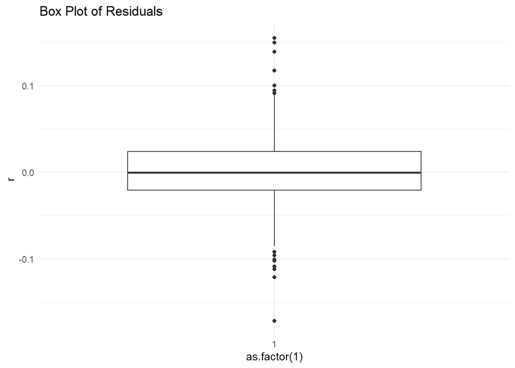

```r
ggplot(r,aes(y=r,x=as.factor(1)))+geom_boxplot()+ggtitle("Box Plot of Residuals")+theme_minimal()
```

Since boxplot is quite symmetric data seems normal. There might be some outliers that can interfere normality of residuals.

*Formal Tests*

H0:Residuals have normal distribution. H1:Residuals don’t have normal distribution.

*Jarque Bera Test*

```r
jarque.bera.test(r)
```

```
##
##  Jarque Bera Test
##
## data:  r
## X-squared = 60.228, df = 2, p-value = 8.349e-14
```

*Shapiro-Wilk Test*

```r
shapiro.test(r)
```

```
##
##  Shapiro-Wilk normality test
##
## data:  r
## W = 0.98834, p-value = 1.472e-05
```

Since p-values of the tests are less than 0.05, we need to reject H0. We cannot say that residuals are normality distributed.

**Serial Autocorrelation**

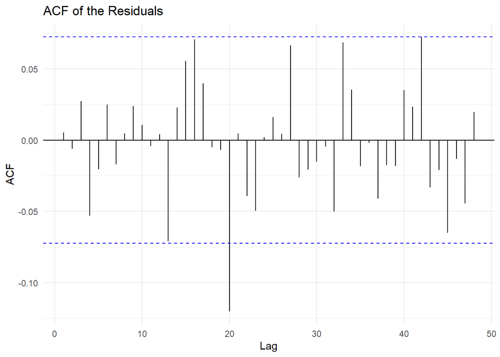

```r
ggAcf(as.vector(r),main="ACF of the Residuals",lag = 48)+theme_minimal()
```

Since majority of the spikes are inside the WN band we can conclude that residuals seems uncorrelated. Apply formal tests to make sure.

*Formal Tests*

H0: no serial correlation of any order up to p H1: serial correlation up to p

*Breusch-Godfrey Test*

```r
m = lm(r ~ 1+zlag(r))
bgtest(m,order=15)
```

```
##
##  Breusch-Godfrey test for serial correlation of order up to 15
##
## data:  m
## LM test = 27.44, df = 15, p-value = 0.02535
```

P-value is less than 0.05, we reject H0. We cannot claim that residuals are uncorrelated according to Breusch-Godfrey Test.

*Box-Ljung Test*

```r
Box.test(r,lag=15,type = c("Ljung-Box"))
```

```
##
##  Box-Ljung test
##
## data:  r
## X-squared = 10.654, df = 15, p-value = 0.7767
```

P-value is greater than 0.05, we fail to reject H0. We can claim that residuals are uncorrelated according to Box-Ljung Test.

*Box-Pierce Test (Modified Version of Box-Ljung Test)*

```r
Box.test(r,lag=15,type = c("Box-Pierce"))
```

```
##
##  Box-Pierce test
##
## data:  r
## X-squared = 10.475, df = 15, p-value = 0.7888
```

P-value is greater than 0.05, we fail to reject H0. We can claim that residuals are uncorrelated according to Box-Pierce Test.

Since 2 tests results in the same claim, we can accept data as uncorrelated.

**Detecting Heteroscedasticity**

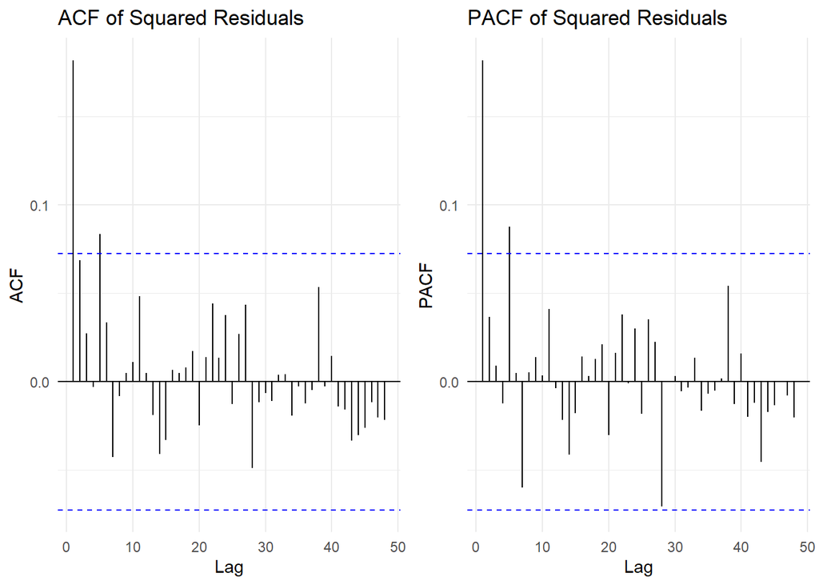

```r
rr=r^2
g1<-ggAcf(as.vector(rr), lag.max = 48)+theme_minimal()+ggtitle("ACF of Squared Residuals")
g2<-ggPacf(as.vector(rr), lag.max = 48)+theme_minimal()+ggtitle("PACF of Squared Residuals")
grid.arrange(g1,g2,ncol=2)
```

There are some big spikes exceeding the WN bands which can show heteroscedasticity.

*Formal Tests*

H0:Residuals are homoscedastic.

H1:Residuals are heteroscedastic.

**Breusch Pagan Test**

```r
m = lm(r ~ msacsr_t+zlag(msacsr_t)+zlag(msacsr_t,2))
bptest(m)
```

```
##
##  studentized Breusch-Pagan test
##
## data:  m
## BP = 0.98289, df = 3, p-value = 0.8054
```

P-value is greater than 0.05, we fail to reject H0. We can claim that residuals are homoscedastic according to Breusch Pagan Test.

**White test**

```r
m1 = lm(r ~ msacsr_t+zlag(msacsr_t)+zlag(msacsr_t,2)+zlag(msacsr_t)^2+zlag(msacsr_t,2)^2+zlag(msacsr_t)*zlag(msacsr_t,2))
bptest(m1)
```

```
##
##  studentized Breusch-Pagan test
##
## data:  m1
## BP = 2.8148, df = 4, p-value = 0.5893
```

P-value is greater than 0.05, we fail to reject H0. We can claim that residuals are homoscedastic according to White Test.

**Engle’s ARCH Test**

H0:Residuals have no ARCH effects.

H1:ARCH(lag) effects are present.

```r
ArchTest(rr)
```

```
##
##  ARCH LM-test; Null hypothesis: no ARCH effects
##
## data:  rr
## Chi-squared = 13.709, df = 12, p-value = 0.3197
```

P-value is greater than 0.05, we fail to reject H0. We can claim that residuals have no ARCH effects. Since there does not seem to be heteroscedasticity, there is no need to apply ARCH and GARCH methods.

**Forecasting**

Forecasting can be applied to the fitted model.

```r
f<-forecast(fit_sarima9,h=12)
f
```

```
##          Point Forecast    Lo 80    Hi 80    Lo 95    Hi 95
## Nov 2023       1.378134 1.330523 1.425745 1.305319 1.450949
## Dec 2023       1.377201 1.317174 1.437228 1.285397 1.469004
## Jan 2024       1.373429 1.303146 1.443711 1.265940 1.480917
## Feb 2024       1.362805 1.283583 1.442027 1.241646 1.483965
## Mar 2024       1.360193 1.272943 1.447442 1.226756 1.493630
## Apr 2024       1.341680 1.247081 1.436279 1.197004 1.486357
## May 2024       1.343088 1.241671 1.444504 1.187984 1.498191
## Jun 2024       1.328781 1.220976 1.436585 1.163908 1.493653
## Jul 2024       1.329362 1.215528 1.443197 1.155268 1.503457
## Aug 2024       1.339774 1.220214 1.459334 1.156922 1.522626
## Sep 2024       1.332416 1.207391 1.457440 1.141208 1.523624
## Oct 2024       1.328129 1.197870 1.458388 1.128915 1.527344
```

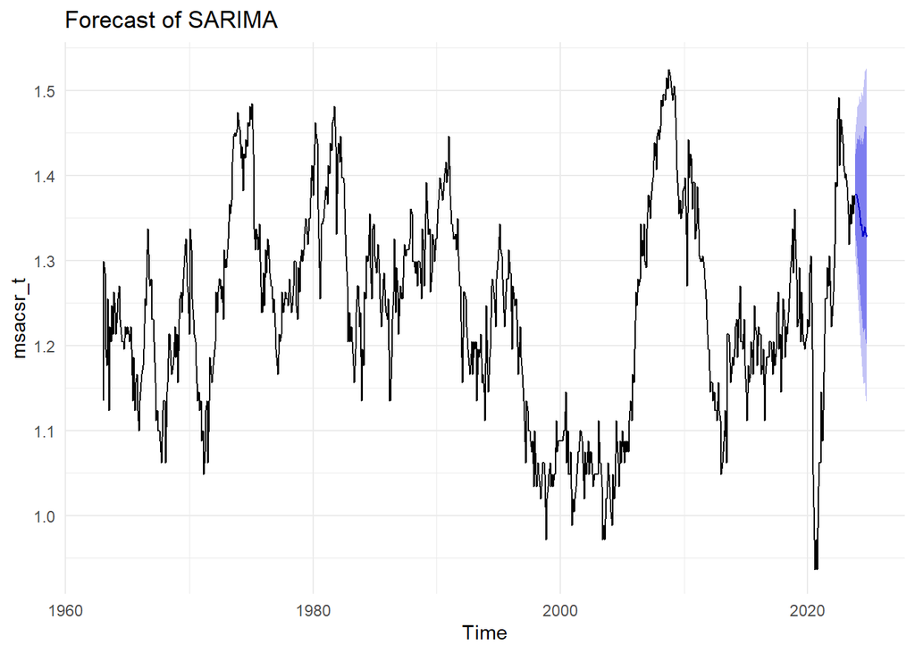

```r
autoplot(f)+theme_minimal()+ggtitle("Forecast of SARIMA")
```

Prediction interval seems wide.

Accuracy can be checked to observe the prediction of the model.

```r
f_t<-InvBoxCox(f$mean,lambda)
accuracy(f_t,msacsr_test)
```

```
##                 ME     RMSE       MAE      MPE     MAPE        ACF1 Theil's U
## Test set 0.9063835 1.065014 0.9063835 10.62228 10.62228 -0.06104231  1.504507
```

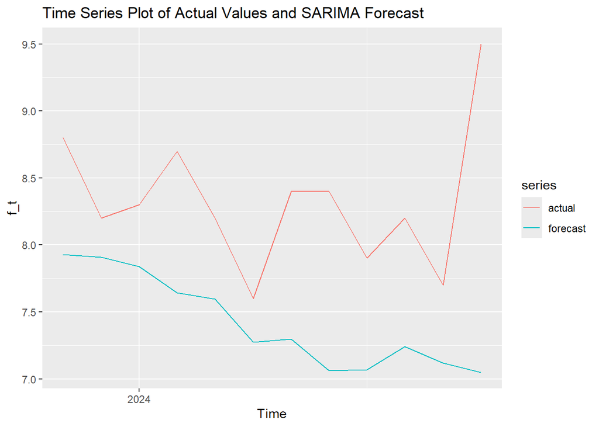

```r
autoplot(f_t,main=c("Time Series Plot of Actual Values and SARIMA Forecast"), series="forecast" ) + autolayer(msacsr_test,series = "actual")
```

**Simple Exponential Smoothing**

Cannot be used since data has seasonality. Use ets function for finding the best exponential smoothing.

```r
msacsr_ets <-ets(msacsr_tr,model="ZZZ")
msacsr_ets
```

```
## ETS(M,Ad,N)
##
## Call:
##  ets(y = msacsr_tr, model = "ZZZ")
##
##   Smoothing parameters:
##     alpha = 0.7717
##     beta  = 3e-04
##     phi   = 0.8
##
##   Initial states:
##     l = 4.1079
##     b = 1.0081
##
##   sigma:  0.0826
##
##      AIC     AICc      BIC
## 3769.408 3769.524 3796.966
```

Ets gives us a model without capturing the seasonality. We should not proceed with ETS in this case but lets calculate accuracy and forecast for the project.

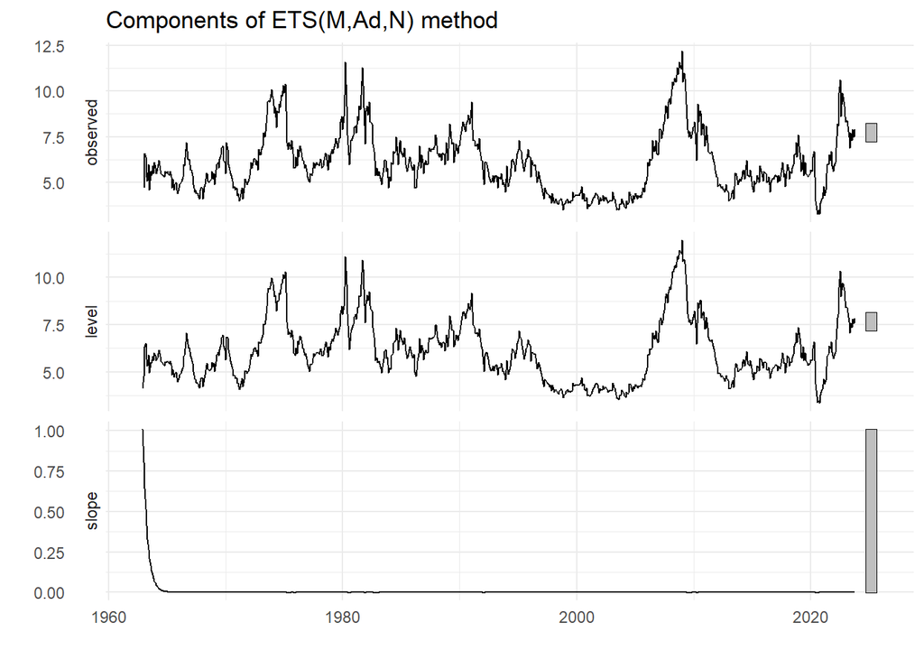

```r
autoplot(msacsr_ets)+theme_minimal()
```

```r
ses_msacsr_f<-forecast(msacsr_ets,h=12)
ses_msacsr_f
```

```
##          Point Forecast    Lo 80     Hi 80    Lo 95     Hi 95
## Nov 2023       7.823064 6.994966  8.651162 6.556597  9.089530
## Dec 2023       7.823070 6.775627  8.870514 6.221143  9.424997
## Jan 2024       7.823076 6.594091  9.052060 5.943506  9.702645
## Feb 2024       7.823080 6.435454  9.210706 5.700889  9.945271
## Mar 2024       7.823083 6.292584  9.353582 5.482387 10.163779
## Apr 2024       7.823086 6.161416  9.484755 5.281782 10.364390
## May 2024       7.823088 6.039370  9.606806 5.095127 10.551049
## Jun 2024       7.823090 5.924687  9.721492 4.919733 10.726446
## Jul 2024       7.823091 5.816106  9.830075 4.753673 10.892509
## Aug 2024       7.823092 5.712687  9.933497 4.595506 11.050678
## Sep 2024       7.823093 5.613704 10.032482 4.444124 11.202062
## Oct 2024       7.823094 5.518585 10.127602 4.298652 11.347535
```

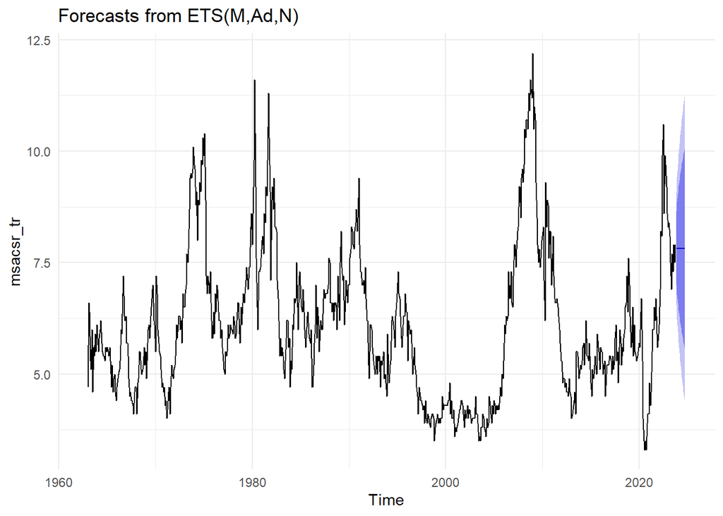

```r
autoplot(ses_msacsr_f)+theme_minimal()
```

```r
accuracy(ses_msacsr_f,msacsr_test)
```

```
##                        ME      RMSE       MAE        MPE     MAPE      MASE
## Training set -0.000562067 0.5368091 0.3913663 -0.4334363 6.328048 0.3449982
## Test set      0.501916271 0.7027064 0.5596127  5.7120064 6.467664 0.4933111
##                     ACF1 Theil's U
## Training set  0.06315762        NA
## Test set     -0.24310288 0.9387185
```

Check normality of residuals of ets:

```r
r1=resid(ses_msacsr_f)
```

```r
jarque.bera.test(r1)
```

```
##
##  Jarque Bera Test
##
## data:  r1
## X-squared = 81.703, df = 2, p-value < 2.2e-16
```

```r
shapiro.test(r1)
```

```
##
##  Shapiro-Wilk normality test
##
## data:  r1
## W = 0.98761, p-value = 7.611e-06
```

Residuals are not normal.

**Double Exponential Smoothing (Holt’s Exponential Smoothing)**

Cannot be used since the data has seasonality.

**Holt Winter’s Exponential Smoothing**

Holt Winter’s exponential smoothing can be used since our data have trend and seasonality.

```r
msacsr_hw<-hw(msacsr_tr, h=13, seasonal="additive")
msacsr_hw$model
```

```
## Holt-Winters' additive method
##
## Call:
##  hw(y = msacsr_tr, h = 13, seasonal = "additive")
##
##   Smoothing parameters:
##     alpha = 0.787
##     beta  = 1e-04
##     gamma = 1e-04
##
##   Initial states:
##     l = 5.7355
##     b = -0.0069
##     s = -0.0446 0.0155 0.0117 0.0341 -0.0518 -0.1005
##            -0.0368 -0.0426 0.0274 0.0467 0.0967 0.0442
##
##   sigma:  0.5428
##
##      AIC     AICc      BIC
## 3938.626 3939.486 4016.708
```

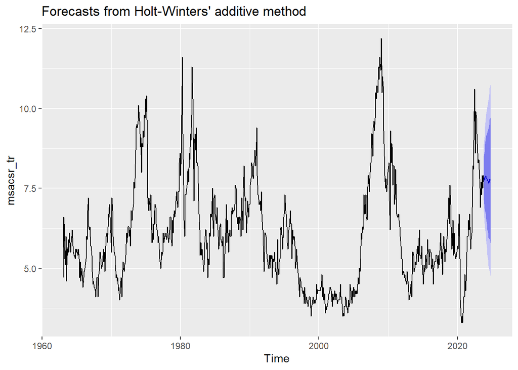

```r
autoplot(msacsr_hw)
```

Forecast of Holt-Winters’ additive method seems quite better so far.

Check normality of residuals of Holt-Winters’ additive method:

```r
r2=resid(msacsr_hw)
```

```r
jarque.bera.test(r2)
```

```
##
##  Jarque Bera Test
##
## data:  r2
## X-squared = 204.94, df = 2, p-value < 2.2e-16
```

```r
shapiro.test(r2)
```

```
##
##  Shapiro-Wilk normality test
##
## data:  r2
## W = 0.97223, p-value = 1.512e-10
```

Residuals are not normal.

Even though seasonality seems additive it is still hard to decide. Try multiplicative model as well.

```r
msacsr_hw2<-hw(msacsr_tr, h=13, seasonal="multiplicative")
msacsr_hw2$model
```

```
## Holt-Winters' multiplicative method
##
## Call:
##  hw(y = msacsr_tr, h = 13, seasonal = "multiplicative")
##
##   Smoothing parameters:
##     alpha = 0.7204
##     beta  = 1e-04
##     gamma = 1e-04
##
##   Initial states:
##     l = 5.5202
##     b = 0.0117
##     s = 0.9941 1.002 1.0069 1.0182 0.9987 1.0015
##            1.0009 0.9922 0.9916 0.9932 1.003 0.9977
##
##   sigma:  0.0834
##
##      AIC     AICc      BIC
## 3797.752 3798.611 3875.833
```

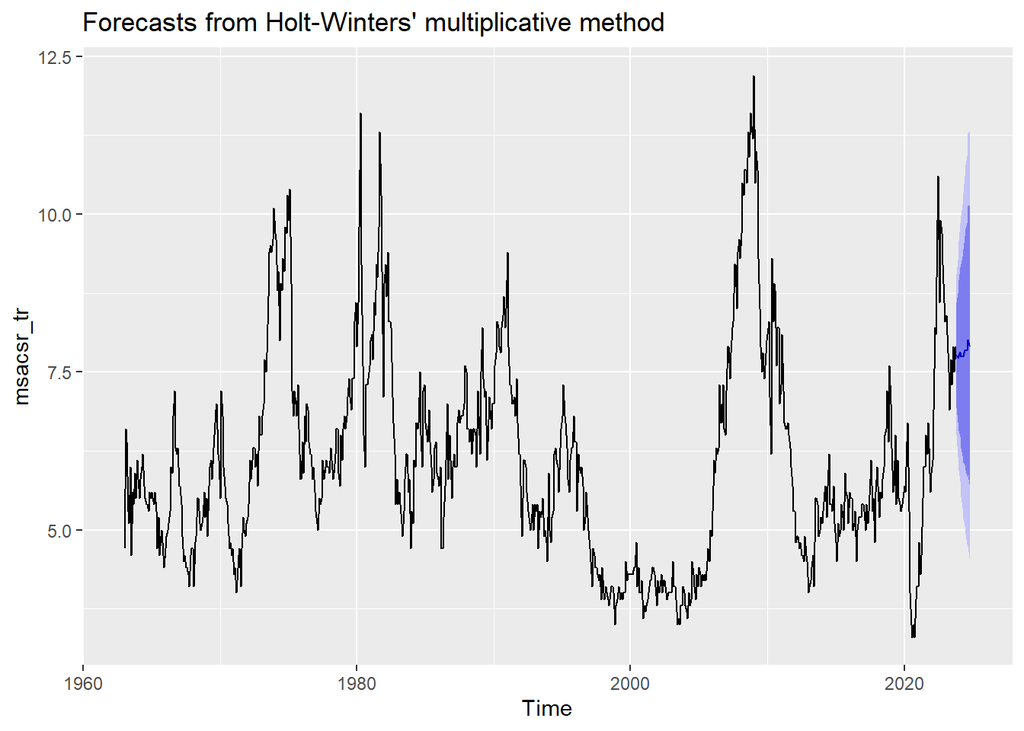

```r
autoplot(msacsr_hw2)
```

Check normality of residuals of Holt-Winters’ multiplicative method:

```r
r3=resid(msacsr_hw2)
```

```r
jarque.bera.test(r3)
```

```
##
##  Jarque Bera Test
##
## data:  r3
## X-squared = 78.686, df = 2, p-value < 2.2e-16
```

```r
shapiro.test(r3)
```

```
##
##  Shapiro-Wilk normality test
##
## data:  r3
## W = 0.98732, p-value = 5.863e-06
```

Residuals are not normal.

These methods can be compared with accuracy.

```r
accuracy(msacsr_hw,msacsr_test)
```

```
##                      ME      RMSE       MAE        MPE     MAPE      MASE
## Training set 0.01191179 0.5368048 0.3938698 -0.2104383 6.378197 0.3472051
## Test set     0.54986571 0.7338176 0.5978176  6.2969033 6.925516 0.5269896
##                     ACF1 Theil's U
## Training set  0.03920971        NA
## Test set     -0.27928736  0.988702
```

```r
accuracy(msacsr_hw2,msacsr_test)
```

```
##                       ME      RMSE       MAE        MPE     MAPE      MASE
## Training set -0.01148002 0.5380965 0.3933394 -0.6446137 6.375890 0.3467375
## Test set      0.50730781 0.7062304 0.5832967  5.7796156 6.770665 0.5141891
##                    ACF1 Theil's U
## Training set  0.1010933        NA
## Test set     -0.2633232  0.930477
```

Second fit seems better as it has smaller RMSE and MAPE values.

**Prophet**

Prophet can be used since there is seasonality in the data. Change the class of the data back to df.

```r
ds<-c(seq(as.Date("1963/01/01"),as.Date("2023/10/01"),by="month"))
head(ds)
```

```
## [1] "1963-01-01" "1963-02-01" "1963-03-01" "1963-04-01" "1963-05-01"
## [6] "1963-06-01"
```

```r
df<-data.frame(ds,y=as.numeric(msacsr_tr))
head(df)
```

|  | ds | y |
| --- | --- | --- |
| 1 | 1963-01-01 | 4.7 |
| 2 | 1963-02-01 | 6.6 |
| 3 | 1963-03-01 | 6.4 |
| 4 | 1963-04-01 | 5.3 |
| 5 | 1963-05-01 | 5.1 |
| 6 | 1963-06-01 | 6.0 |

Apply prophet to the data to find its model.

```r
msacsr_prophet <- prophet(df)
future_df<-make_future_dataframe(msacsr_prophet,periods = 12)
tail(future_df)
```

|  | ds |
| --- | --- |
| 737 | 2023-10-08 |
| 738 | 2023-10-09 |
| 739 | 2023-10-10 |
| 740 | 2023-10-11 |
| 741 | 2023-10-12 |
| 742 | 2023-10-13 |

Following codes should be used to draw the forecast of the prophet model.

```r
forecast <- predict(msacsr_prophet, future_df)
tail(forecast[c('ds', 'yhat', 'yhat_lower', 'yhat_upper')],12)
```

|  | ds | yhat | yhat_lower | yhat_upper |
| --- | --- | --- | --- | --- |
| 731 | 2023-10-02 | 6.547982 | 4.499273 | 8.471607 |
| 732 | 2023-10-03 | 6.572212 | 4.549941 | 8.596157 |
| 733 | 2023-10-04 | 6.578410 | 4.569938 | 8.386640 |
| 734 | 2023-10-05 | 6.565924 | 4.759726 | 8.485294 |
| 735 | 2023-10-06 | 6.534656 | 4.568801 | 8.443923 |
| 736 | 2023-10-07 | 6.485074 | 4.560533 | 8.342803 |
| 737 | 2023-10-08 | 6.418213 | 4.434089 | 8.336757 |
| 738 | 2023-10-09 | 6.335656 | 4.288747 | 8.349143 |
| 739 | 2023-10-10 | 6.239497 | 4.312468 | 8.158995 |
| 740 | 2023-10-11 | 6.132294 | 4.180165 | 8.125573 |

[output cut: 2 more lines]

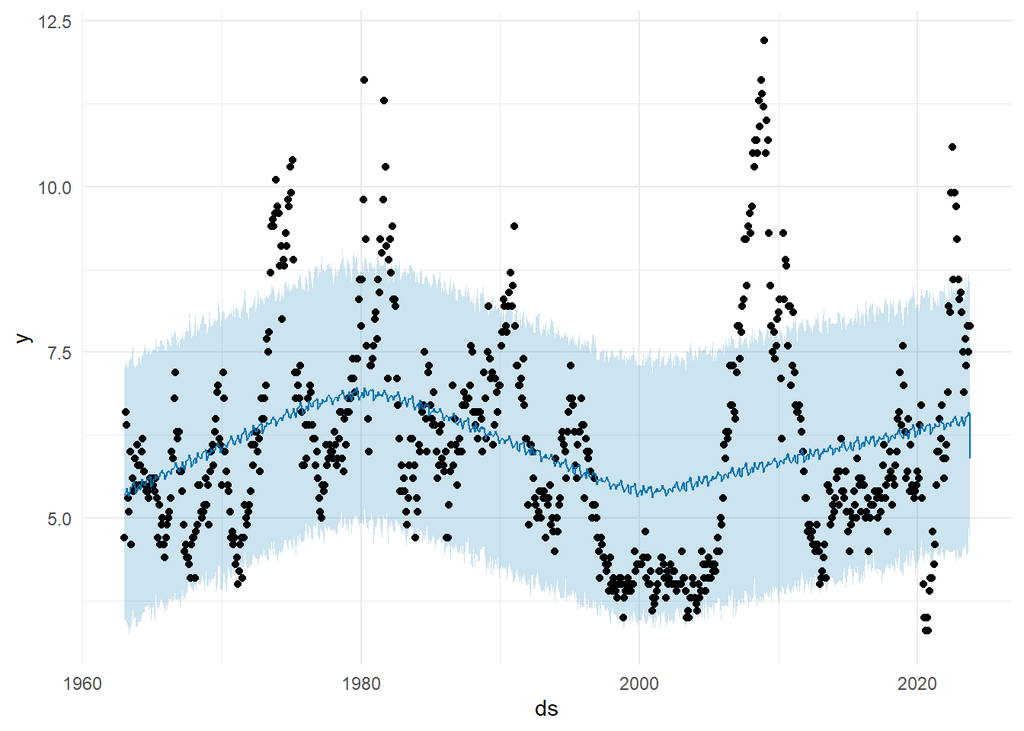

```r
plot(msacsr_prophet, forecast)+theme_minimal()
```

Model is a bad fit from the plot. Predicted values are shown with blue line and light blue area shows upper and lower yhat values, none looks closer to actual values shown with black dots.

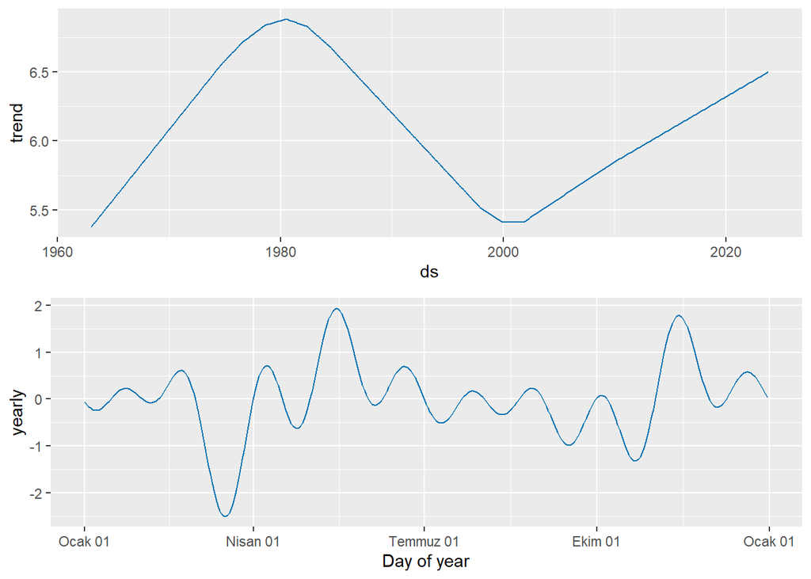

```r
prophet_plot_components(msacsr_prophet, forecast)
```

Trend and seasonality of prophet model can be seen above.

```r
accuracy(tail(forecast$yhat,12),msacsr_test)
```

```
##                ME   RMSE      MAE      MPE     MAPE       ACF1 Theil's U
## Test set 1.964681 2.0472 1.964681 23.32338 23.32338 -0.1050801  2.778879
```

Accuracy of Holt Winters’ Exponential Smoothing is better than prophet.

**Hyper Parameter Tuning**

```r
changepoint_prior <- c(0.1, 0.5, 0.9)
seasonality_prior <- c(0.1, 0.3, 0.5)
changepoint_range <- c(0.6, 0.8, 0.9)

results <- data.frame(
  changepoint_prior = numeric(),
  seasonality_prior = numeric(),
  changepoint_range = numeric(),
  RMSE = numeric()
)

for (cp in changepoint_prior) {
  for (sp in seasonality_prior) {
    for (cr in changepoint_range) {
      m <- prophet(
        changepoint.prior.scale = cp,
        seasonality.prior.scale = sp,
        changepoint.range = cr
      )
      m <- fit.prophet(m, df)


      future <- make_future_dataframe(m, periods = 12, freq = "month")
      forecast <- predict(m, future)

      predicted <- tail(forecast$yhat, 12)
      acc <- accuracy(predicted, msacsr_test)
      rmse <- acc["Test set", "RMSE"]  # Extract RMSE from accuracy

      results <- rbind(results, data.frame(
        changepoint_prior = cp,
        seasonality_prior = sp,
        changepoint_range = cr,
        RMSE = rmse
      ))
    }
  }
}

#best parameters
best_params <- results[which.min(results$RMSE), ]
best_params
```

|  | changepoint_prior | seasonality_prior | changepoint_range | RMSE |
| --- | --- | --- | --- | --- |
| 21 | 0.9 | 0.1 | 0.9 | 0.8166002 |

When changepoint_prior=0.9, seasonality_prior=0.1, changepoint_range=0.9 we obtain the min RMSE.

Let us create a new prophet.

```r
msacsr_prophet_new <- prophet(df, changepoint.range=0.9,changepoint.prior.scale=0.9,seasonality.prior.scale=0.1)
future_df_new<-make_future_dataframe(msacsr_prophet,periods = 12)
forecast_new <- predict(msacsr_prophet_new, future_df_new)
```

```r
plot(msacsr_prophet_new, forecast)+theme_minimal()
```

[output not shown]

Check normality of residuals of Prophet method:

```r
r4 <- df$y - forecast_new$yhat[1:nrow(df)]
```

```r
jarque.bera.test(r4)
```

```
##
##  Jarque Bera Test
##
## data:  r4
## X-squared = 159.25, df = 2, p-value < 2.2e-16
```

```r
shapiro.test(r4)
```

```
##
##  Shapiro-Wilk normality test
##
## data:  r4
## W = 0.96986, p-value = 4.062e-11
```

Residuals are not normal.

```r
accuracy(tail(forecast_new$yhat,12),msacsr_test)
```

```
##                 ME      RMSE       MAE      MPE     MAPE       ACF1 Theil's U
## Test set 0.8075036 0.9710007 0.8097851 9.375053 9.405073 -0.1754445  1.310324
```

**TBATS**

For TBATS model we do not use the transformed model. TBATS can be applied since the data has seasonality. TBATS model is applied with following code:

```r
msacsr_tbats<-tbats(msacsr_train)
msacsr_tbats
```

```
## BATS(0.007, {0,0}, 0.962, -)
##
## Call: tbats(y = msacsr_train)
##
## Parameters
##   Lambda: 0.007073
##   Alpha: 0.8142833
##   Beta: -0.02895611
##   Damping Parameter: 0.962059
##
## Seed States:
##            [,1]
## [1,] 1.60270889
## [2,] 0.01563881
## attr(,"lambda")
## [1] 0.007072946
##
## Sigma: 0.08148824
## AIC: 3734.082
```

Lambda value is 0.007, data is transformed to y^0.007

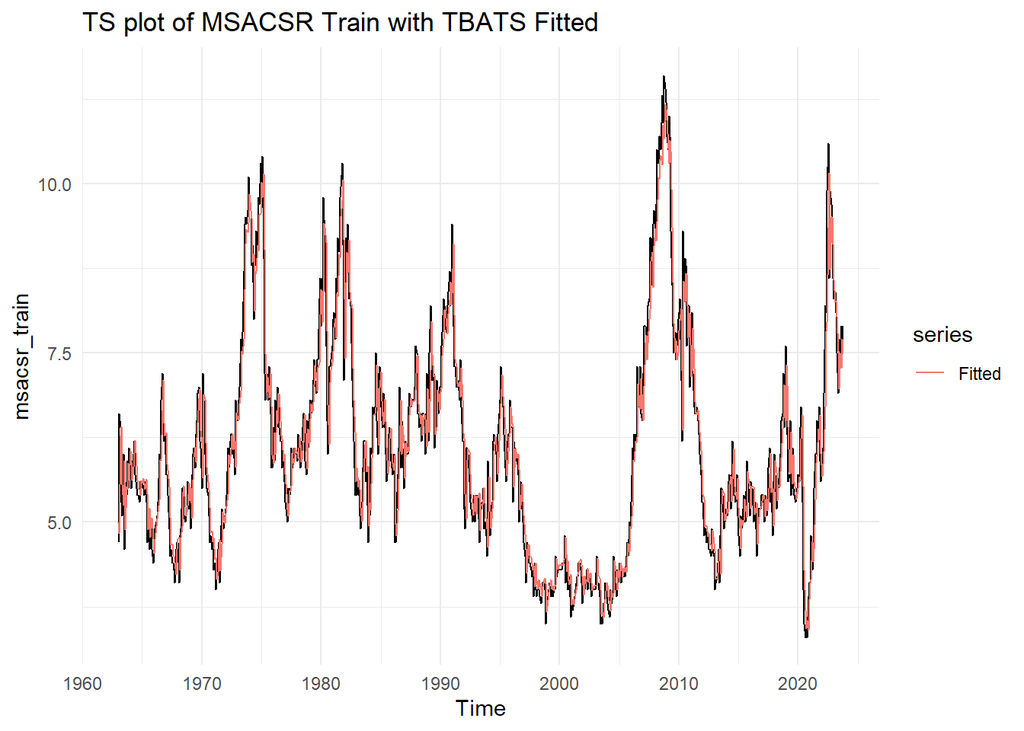

```r
autoplot(msacsr_train,main="TS plot of MSACSR Train with TBATS Fitted") +autolayer(fitted(msacsr_tbats), series="Fitted") +theme_minimal()
```

TBATS is doing a good job at matching the original plot. Its forecast can be found as well.

```r
msacsr_tbats_forecast<-forecast(msacsr_tbats,h=12)
msacsr_tbats_forecast
```

```
##          Point Forecast    Lo 80    Hi 80    Lo 95     Hi 95
## Nov 2023       7.745960 6.988066 8.585409 6.617156  9.065735
## Dec 2023       7.675775 6.733220 8.749212 6.281751  9.376495
## Jan 2024       7.608848 6.531891 8.861912 6.024533  9.606103
## Feb 2024       7.545008 6.363371 8.944234 5.814234  9.786305
## Mar 2024       7.484092 6.217897 9.005945 5.636234  9.932137
## Apr 2024       7.425948 6.089865 9.052645 5.482223 10.052287
## May 2024       7.370434 5.975666 9.087926 5.346906 10.152378
## Jun 2024       7.317415 5.872800 9.114267 5.226655 10.236336
## Jul 2024       7.266765 5.779438 9.133468 5.118843 10.307045
## Aug 2024       7.218365 5.694189 9.146886 5.021497 10.366709
## Sep 2024       7.172104 5.615962 9.155573 4.933089 10.417059
## Oct 2024       7.127876 5.543882 9.160361 4.852403 10.459487
```

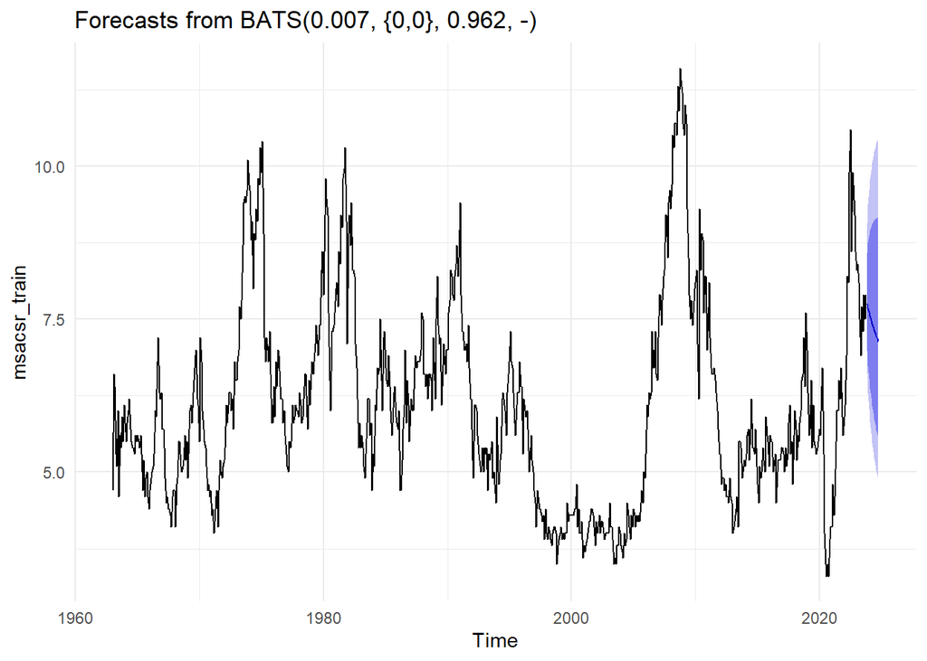

```r
autoplot(msacsr_tbats_forecast)+theme_minimal()
```

Prediciton interval seems quite wide.

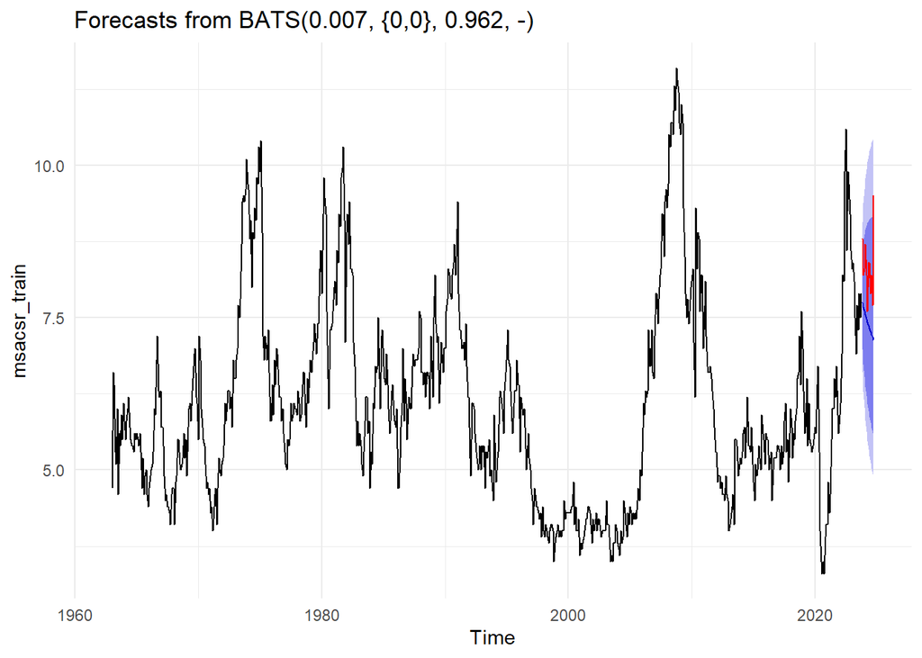

```r
autoplot(msacsr_tbats_forecast)+autolayer(msacsr_test,series="actual",color="red")+theme_minimal()
```

TBATS forecast seems off from the test set.

Check normality of residuals of TBATS method:

```r
r5=resid(msacsr_tbats_forecast)
```

```r
jarque.bera.test(r5)
```

```
##
##  Jarque Bera Test
##
## data:  r5
## X-squared = 49.829, df = 2, p-value = 1.513e-11
```

```r
shapiro.test(r5)
```

```
##
##  Shapiro-Wilk normality test
##
## data:  r5
## W = 0.99092, p-value = 0.0001814
```

Residuals are not normal.

Accuracy can be computed.

```r
accuracy(msacsr_tbats_forecast,msacsr_test)
```

```
##                       ME      RMSE       MAE        MPE      MAPE      MASE
## Training set 0.001423906 0.5121801 0.3802975 -0.6319701  6.214897 0.3393918
## Test set     0.911784357 1.0504987 0.9117844 10.6626128 10.662613 0.8137108
##                     ACF1 Theil's U
## Training set  0.02277538        NA
## Test set     -0.19827802  1.460337
```

**Neural Network**

Construct NN model,

```r
msacsr_nnmodel<-nnetar(msacsr_tr)
msacsr_nnmodel
```

```
## Series: msacsr_tr
## Model:  NNAR(25,1,13)[12]
## Call:   nnetar(y = msacsr_tr)
##
## Average of 20 networks, each of which is
## a 25-13-1 network with 352 weights
## options were - linear output units
##
## sigma^2 estimated as 0.03879
```

The obtained model is NNAR(25,1,13)[12], there are 13 neurons in the hidden layer.

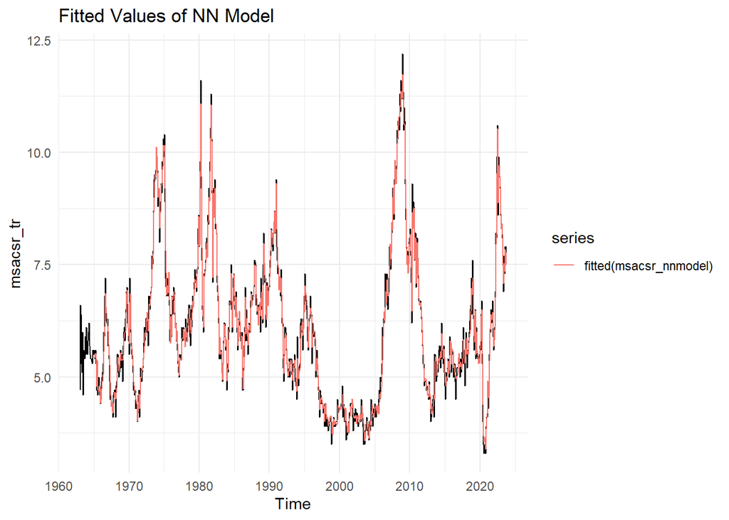

```r
autoplot(msacsr_tr)+autolayer(fitted(msacsr_nnmodel))+theme_minimal()+ggtitle("Fitted Values of NN Model")
```

Lines seems to fit.

Obtain forecast now.

```r
msacsr_nnforecast<-forecast(msacsr_nnmodel,h=12,PI=TRUE)
msacsr_nnforecast
```

```
##          Point Forecast    Lo 80    Hi 80    Lo 95    Hi 95
## Nov 2023       8.494236 8.255167 8.739716 8.108190 8.858998
## Dec 2023       7.950450 7.646967 8.233430 7.476720 8.396856
## Jan 2024       7.989627 7.602030 8.345053 7.355444 8.497169
## Feb 2024       7.680552 7.217083 8.145490 6.929935 8.335146
## Mar 2024       6.946238 6.511532 7.404862 6.291952 7.603133
## Apr 2024       7.517995 6.990549 8.034154 6.733554 8.284824
## May 2024       7.006554 6.466615 7.519633 6.177374 7.826134
## Jun 2024       6.875584 6.376126 7.347033 6.112820 7.620231
## Jul 2024       7.359444 6.753129 7.805835 6.512380 8.080492
## Aug 2024       7.366451 6.539981 7.995248 6.190730 8.400325
## Sep 2024       6.877723 6.095204 7.530590 5.694478 7.899474
## Oct 2024       6.857909 6.011519 7.459825 5.670661 7.853313
```

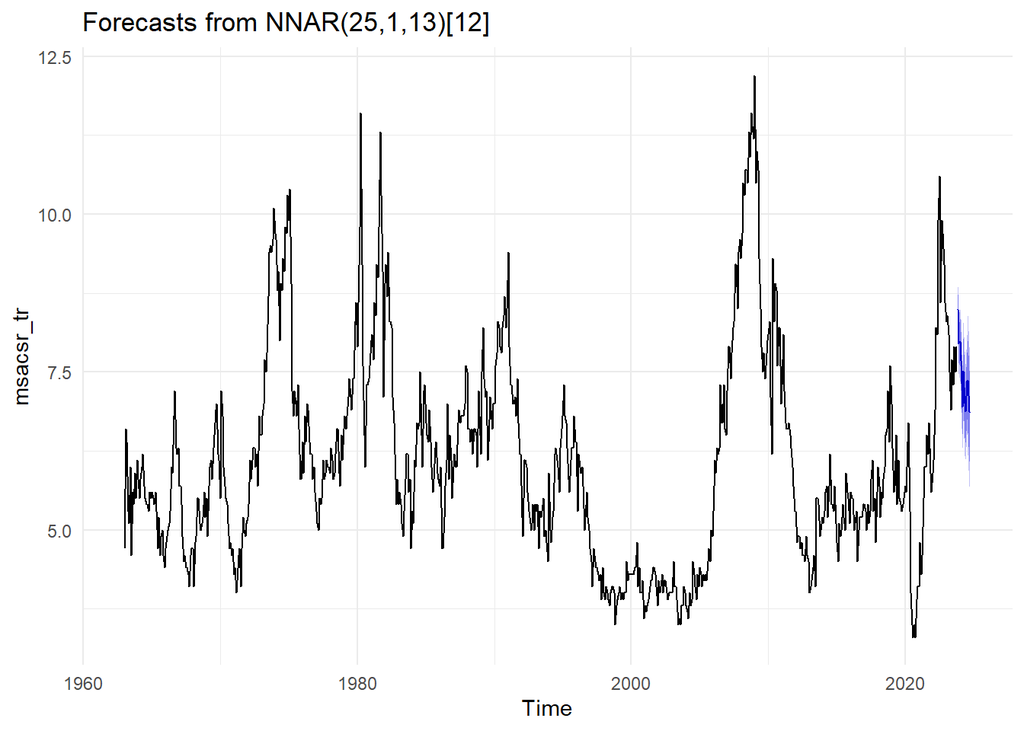

```r
autoplot(msacsr_nnforecast)+theme_minimal()
```

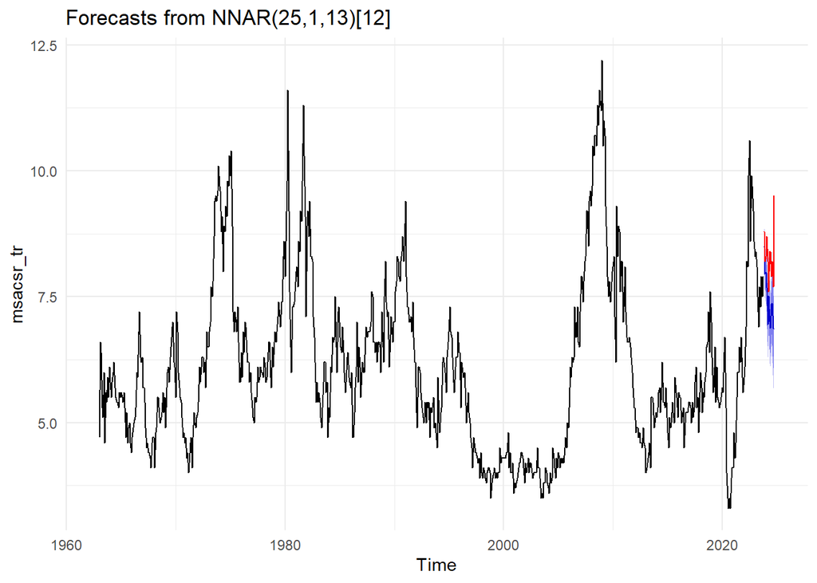

```r
autoplot(msacsr_nnforecast)+autolayer(msacsr_test,series="actual",color="red")+theme_minimal()
```

Prediction interval seems narrower, however its forecast is visibly bad. Accuracy function will make it easier to compare between forecasts as its predicted line seems very off.

```r
accuracy(msacsr_nnforecast,msacsr_test)
```

```
##                        ME      RMSE       MAE        MPE      MAPE      MASE
## Training set -0.001294654 0.1969588 0.1471173 -0.2493509  2.570891 0.1296872
## Test set      0.914769814 1.1467107 0.9147698 10.7148737 10.714874 0.8063901
##                      ACF1 Theil's U
## Training set -0.010006761        NA
## Test set      0.007023529   1.65744
```

MAPE seems too big but an overall comparison with other forecasts will be more logical.

*Changing the parameters of NNTAR*

Make the number of neurons in the hidden layers 15.

```r
msacsr_nnmodel_new<-nnetar(msacsr_tr, size=15)
msacsr_nnmodel_new
```

```
## Series: msacsr_tr
## Model:  NNAR(25,1,15)[12]
## Call:   nnetar(y = msacsr_tr, size = 15)
##
## Average of 20 networks, each of which is
## a 25-15-1 network with 406 weights
## options were - linear output units
##
## sigma^2 estimated as 0.03273
```

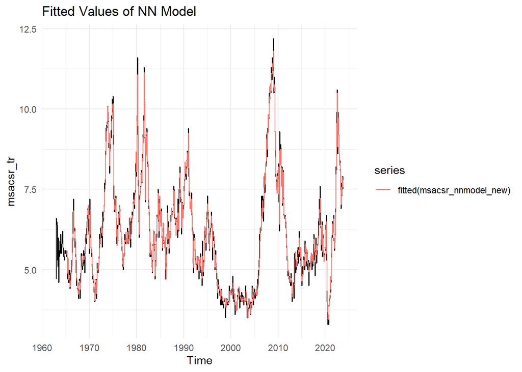

```r
autoplot(msacsr_tr)+autolayer(fitted(msacsr_nnmodel_new))+theme_minimal()+ggtitle("Fitted Values of NN Model")
```

```r
msacsr_nnforecast_new<-forecast(msacsr_nnmodel_new,h=12,PI=TRUE)
msacsr_nnforecast_new
```

```
##          Point Forecast    Lo 80    Hi 80    Lo 95    Hi 95
## Nov 2023       7.946656 7.721761 8.183455 7.605924 8.321968
## Dec 2023       6.915730 6.633380 7.210811 6.477769 7.349750
## Jan 2024       6.681193 6.335374 6.997457 6.195398 7.196686
## Feb 2024       6.362066 6.012471 6.696208 5.854991 6.875143
## Mar 2024       5.875885 5.560866 6.197184 5.393396 6.374978
## Apr 2024       6.393826 5.965763 6.864537 5.781573 7.102652
## May 2024       6.342901 5.939694 6.761687 5.702037 6.932618
## Jun 2024       6.104427 5.708235 6.495889 5.521159 6.697806
## Jul 2024       6.037881 5.588149 6.547588 5.381752 6.801816
## Aug 2024       5.776051 5.335347 6.287299 5.120438 6.563873
## Sep 2024       5.370019 5.035638 5.757299 4.845211 6.035593
## Oct 2024       5.355125 5.050089 5.798935 4.816194 6.020806
```

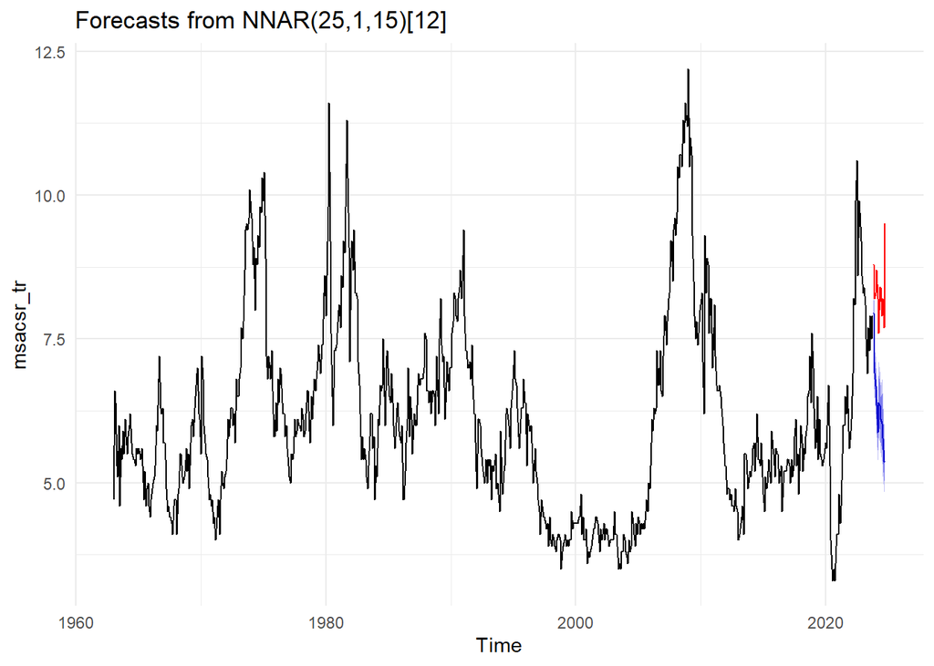

```r
autoplot(msacsr_nnforecast_new)+autolayer(msacsr_test,series="actual",color="red")+theme_minimal()
```

```r
accuracy(msacsr_nnforecast_new,msacsr_test)
```

```
##                         ME      RMSE       MAE        MPE      MAPE      MASE
## Training set -4.635775e-05 0.1809194 0.1346732 -0.2071258  2.370794 0.1187175
## Test set      2.061520e+00 2.2130957 2.0615200 24.5656464 24.565646 1.8172760
##                     ACF1 Theil's U
## Training set -0.01006375        NA
## Test set      0.19924564   3.14871
```

**CHECKING ACCURACIES**

SARIMA:

```r
f_t<-InvBoxCox(f$mean,lambda)
accuracy(f_t,msacsr_test)
```

```
##                 ME     RMSE       MAE      MPE     MAPE        ACF1 Theil's U
## Test set 0.9063835 1.065014 0.9063835 10.62228 10.62228 -0.06104231  1.504507
```

```r
fit_t <- InvBoxCox(fitted(f),lambda)
train_acc <- accuracy(fit_t, msacsr_train)
print(train_acc)
```

```
##                  ME      RMSE       MAE        MPE     MAPE       ACF1
## Test set 0.02165894 0.4986503 0.3732239 -0.1319282 6.070563 0.02797001
##          Theil's U
## Test set 0.9483024
```

ETS:

```r
accuracy(ses_msacsr_f,msacsr_test)
```

```
##                        ME      RMSE       MAE        MPE     MAPE      MASE
## Training set -0.000562067 0.5368091 0.3913663 -0.4334363 6.328048 0.3449982
## Test set      0.501916271 0.7027064 0.5596127  5.7120064 6.467664 0.4933111
##                     ACF1 Theil's U
## Training set  0.06315762        NA
## Test set     -0.24310288 0.9387185
```

Holt Winter’s Exponential Smoothing: *Additive:*

```r
accuracy(msacsr_hw,msacsr_test)
```

```
##                      ME      RMSE       MAE        MPE     MAPE      MASE
## Training set 0.01191179 0.5368048 0.3938698 -0.2104383 6.378197 0.3472051
## Test set     0.54986571 0.7338176 0.5978176  6.2969033 6.925516 0.5269896
##                     ACF1 Theil's U
## Training set  0.03920971        NA
## Test set     -0.27928736  0.988702
```

*Multiplicative:*

```r
accuracy(msacsr_hw2,msacsr_test)
```

```
##                       ME      RMSE       MAE        MPE     MAPE      MASE
## Training set -0.01148002 0.5380965 0.3933394 -0.6446137 6.375890 0.3467375
## Test set      0.50730781 0.7062304 0.5832967  5.7796156 6.770665 0.5141891
##                    ACF1 Theil's U
## Training set  0.1010933        NA
## Test set     -0.2633232  0.930477
```

```r
accuracy(tail(forecast$yhat,12),msacsr_test)
```

```
##                 ME      RMSE       MAE      MPE    MAPE       ACF1 Theil's U
## Test set 0.6317004 0.8215515 0.6967387 7.262393 8.11273 -0.1266236  1.029573
```

```r
accuracy(forecast$yhat, msacsr_train)
```

```
##                    ME      RMSE       MAE       MPE     MAPE      ACF1
## Test set -0.006828546 0.8113189 0.5980598 -1.964642 10.00961 0.7946226
##          Theil's U
## Test set  1.680301
```

Prophet with Hyperparameter tuning:

```r
accuracy(tail(forecast_new$yhat,12),msacsr_test)
```

```
##                 ME      RMSE       MAE      MPE     MAPE       ACF1 Theil's U
## Test set 0.8075036 0.9710007 0.8097851 9.375053 9.405073 -0.1754445  1.310324
```

```r
accuracy(forecast_new$yhat, msacsr_train)
```

```
##                    ME      RMSE       MAE       MPE     MAPE      ACF1
## Test set -0.007353131 0.8129922 0.5997067 -1.987344 10.03442 0.7964649
##          Theil's U
## Test set  1.681929
```

TBATS:

```r
accuracy(msacsr_tbats_forecast,msacsr_test)
```

```
##                       ME      RMSE       MAE        MPE      MAPE      MASE
## Training set 0.001423906 0.5121801 0.3802975 -0.6319701  6.214897 0.3393918
## Test set     0.911784357 1.0504987 0.9117844 10.6626128 10.662613 0.8137108
##                     ACF1 Theil's U
## Training set  0.02277538        NA
## Test set     -0.19827802  1.460337
```

NN:

```r
accuracy(msacsr_nnforecast_new,msacsr_test)
```

```
##                         ME      RMSE       MAE        MPE      MAPE      MASE
## Training set -4.635775e-05 0.1809194 0.1346732 -0.2071258  2.370794 0.1187175
## Test set      2.061520e+00 2.2130957 2.0615200 24.5656464 24.565646 1.8172760
##                     ACF1 Theil's U
## Training set -0.01006375        NA
## Test set      0.19924564   3.14871
```

ETS and Holt Winters’ Multiplicative model has the minimum RMSE and MAPE values, it has the best forecasting performance compared to other forecasts.

The plots of TBATS and NN seemed like a good fit for the train set but its performance with forecasting shows that there can be an overfitting problem with these approaches. As NN has a really bad forecast an overfitting is highly possible.

**PLOT**

**SARIMA** Take inverse transform for plot:

```r
f1<-forecast(fit_sarima9,h=12)
f1$mean <- InvBoxCox(f$mean, lambda)
f1$lower <- InvBoxCox(f$lower, lambda)
f1$upper <- InvBoxCox(f$upper, lambda)
fitted_sarima <- InvBoxCox(fitted(fit_sarima9), lambda)
```

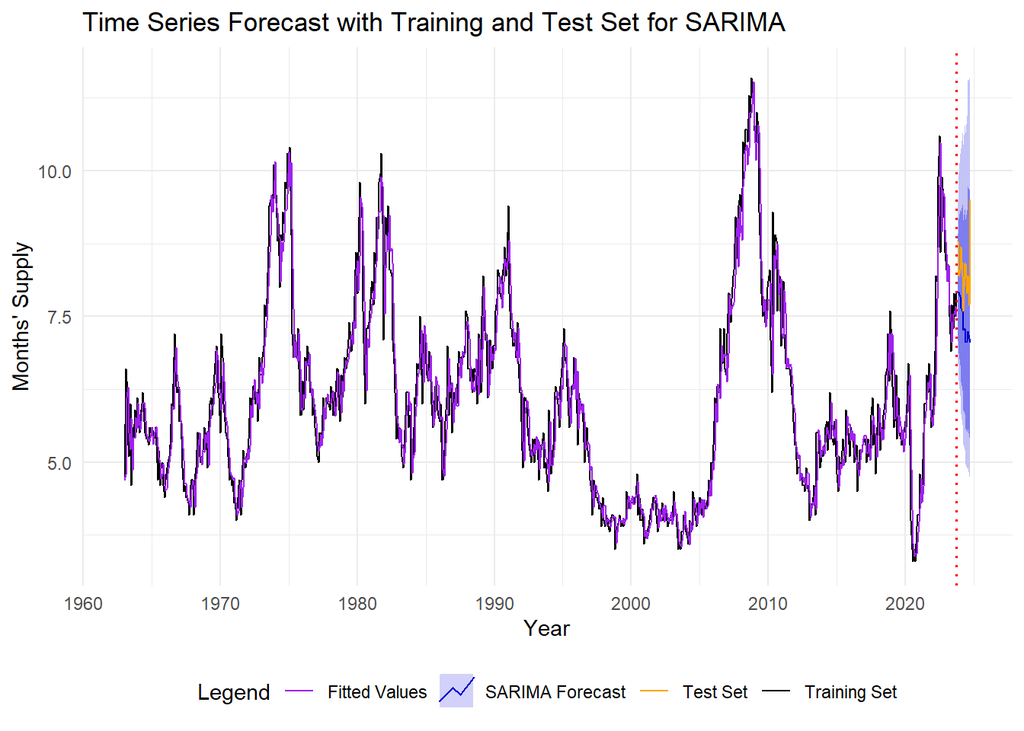

```r
autoplot(msacsr_train, series = "Training Set") +
  autolayer(f1, series = "SARIMA Forecast", PI = TRUE) +
  autolayer(msacsr_test, series = "Test Set") +
  autolayer(fitted_sarima, series = "Fitted Values") +
  labs(
    title = "Time Series Forecast with Training and Test Set for SARIMA",
    x = "Year",
    y = "Months' Supply",
    color = "Legend"
  ) +
  scale_color_manual(
    values = c(
      "Training Set" = "black",
      "SARIMA Forecast" = "navy",
      "Test Set" = "orange",
      "Fitted Values" = "purple"
    )
  ) +
  geom_vline(xintercept = 2023.75, linetype = "dotted", color = "red", linewidth = 0.7) +
  theme_minimal() +   theme(legend.position = "bottom")
```

**ETS**

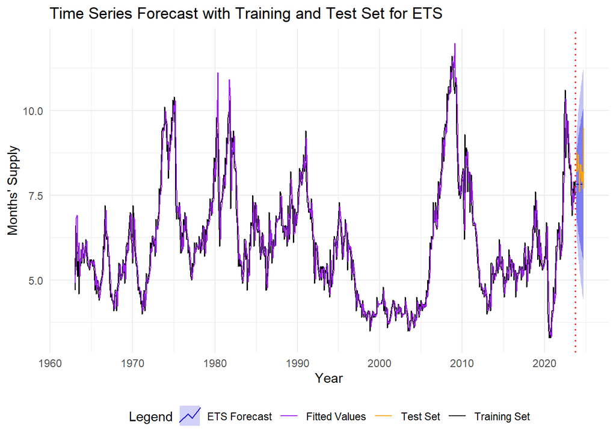

```r
autoplot(msacsr_train, series = "Training Set") +
  autolayer(ses_msacsr_f, series = "ETS Forecast", PI = TRUE) +
  autolayer(msacsr_test, series = "Test Set") +
  autolayer(fitted(ses_msacsr_f), series = "Fitted Values") +
  labs(
    title = "Time Series Forecast with Training and Test Set for ETS",
    x = "Year",
    y = "Months' Supply",
    color = "Legend"
  ) +
  scale_color_manual(
    values = c(
      "Training Set" = "black",
      "ETS Forecast" = "navy",
      "Test Set" = "orange",
      "Fitted Values" = "purple"
    )
  ) +
  geom_vline(xintercept = 2023.75, linetype = "dotted", color = "red", linewidth = 0.7) +
  theme_minimal()+   theme(legend.position = "bottom")
```

**Holt Winters’ Exponential Smoothing**

Holt Winters’ Additive Model

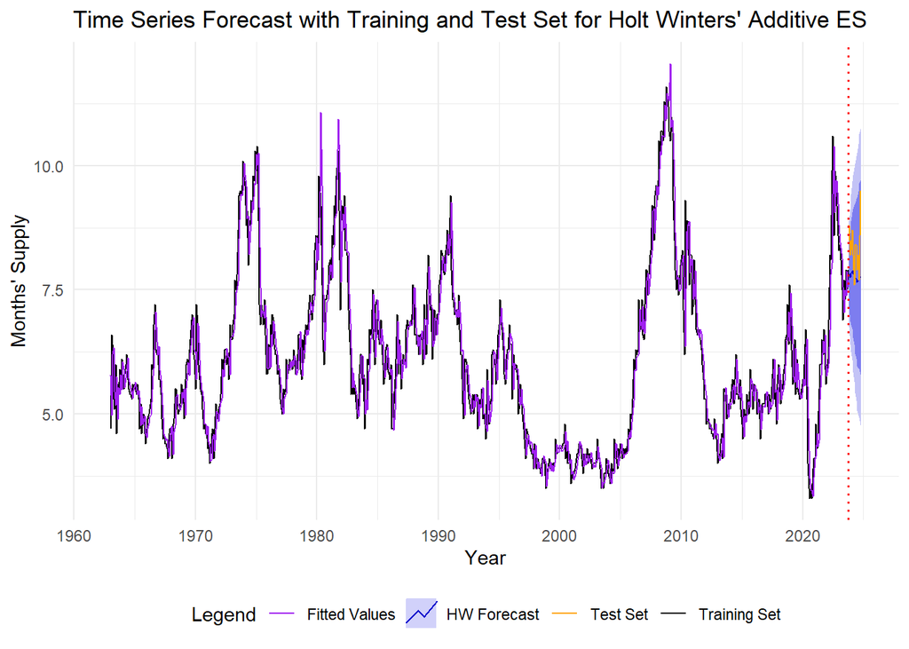

```r
autoplot(msacsr_train, series = "Training Set") +
  autolayer(msacsr_hw, series = "HW Forecast", PI = TRUE) +
  autolayer(msacsr_test, series = "Test Set") +
  autolayer(fitted(msacsr_hw), series = "Fitted Values") +
  labs(
    title = "Time Series Forecast with Training and Test Set for Holt Winters' Additive ES",
    x = "Year",
    y = "Months' Supply",
    color = "Legend"
  ) +
  scale_color_manual(
    values = c(
      "Training Set" = "black",
      "HW Forecast" = "navy",
      "Test Set" = "orange",
      "Fitted Values" = "purple"
    )
  ) +
  geom_vline(xintercept = 2023.75, linetype = "dotted", color = "red", linewidth = 0.7) +
  theme_minimal()+   theme(legend.position = "bottom")
```

Holt Winter’s Multiplicative Model

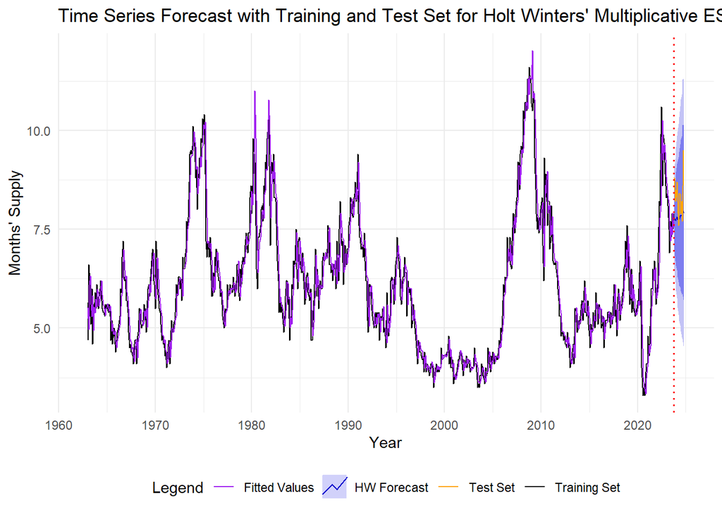

```r
autoplot(msacsr_train, series = "Training Set") +
  autolayer(msacsr_hw2, series = "HW Forecast", PI = TRUE) +
  autolayer(msacsr_test, series = "Test Set") +
  autolayer(fitted(msacsr_hw2), series = "Fitted Values") +
  labs(
    title = "Time Series Forecast with Training and Test Set for Holt Winters' Multiplicative ES",
    x = "Year",
    y = "Months' Supply",
    color = "Legend"
  ) +
  scale_color_manual(
    values = c(
      "Training Set" = "black",
      "HW Forecast" = "navy",
      "Test Set" = "orange",
      "Fitted Values" = "purple"
    )
  ) +
  geom_vline(xintercept = 2023.75, linetype = "dotted", color = "red", linewidth = 0.7) +
  theme_minimal()+   theme(legend.position = "bottom")
```

**Prophet**

```r
plot(msacsr_prophet, forecast)+  theme_minimal()
```

[output not shown]

**Prophet with Hyperparameter Tuning**

```r
plot(msacsr_prophet_new, forecast)+theme_minimal()
```

[output not shown]